# Bootstrapped estimation of D scores for individual participants

Ian Hussey

05 April 2021

# Overview

IRAP trial-type *D* scores are calculated from an average of only 18 pairs of reaction times. This would be deemed as far too low anywhere else in the literature on reaction time based tasks. The implications of this can be seen in how poorly estimated any one IRAP D score is. We can observe this by bootstrapping reaction times for each participant’s *D* scores and noting how wide their confidence intervals are.

```r
# dependencies
library(tidyverse)
library(knitr)
library(kableExtra)
library(rsample)
library(broom)
library(purrr)
library(furrr)
library(pim)
library(boot)
library(parallel)
library(bayestestR)
library(patchwork)
library(mdthemes)
library(lme4)
library(sjPlot)
library(emmeans)
library(ggstance)


# set seed for reproducibility
set.seed(42)

# number of bootstraps
n_boots <- 2000

# run furrr:::future_map in parallel
plan(multiprocess)

# options
options(knitr.table.format = "html") # necessary configuration of tables

# disable scientific notation
options(scipen = 999)


# function to round all numeric vars in a data frame
round_df <- function(df, n_digits = 3) {
  df %>% mutate_if(is.numeric, round, digits = n_digits)
}


# get data from evaluative IRAPs
data_trial_level <- read_csv("../data/data_trial_level.csv") %>%
  filter(timepoint == "baseline")

# outliers
data_outliers <- data_trial_level %>%
  distinct(unique_id, .keep_all = TRUE) %>%
  select(unique_id, domain, mean_rt) %>%
  mutate(median_mean_rt = median(mean_rt, na.rm = TRUE),
         mad_mean_rt = mad(mean_rt, na.rm = TRUE)) %>%
  # exclude median +- 2MAD
  mutate(rt_outlier = ifelse(mean_rt < median_mean_rt-mad_mean_rt*2 |
                               mean_rt > median_mean_rt+mad_mean_rt*2, TRUE, FALSE)) %>%
  filter(rt_outlier == FALSE) %>%
  select(unique_id, rt_outlier) %>%
  full_join(data_trial_level, by = "unique_id") %>%
  mutate(rt_outlier = ifelse(is.na(rt_outlier), TRUE, rt_outlier))

data_outliers_removed <- data_outliers %>%
  filter(rt_outlier == FALSE)

# trim RTs>10000 ms, as part of D scoring
data_trimmed <- data_outliers_removed %>%
  select(unique_id, domain, trial_type, rt, block_type) %>%
  filter(rt <= 10000)

# for plot
dodge_width <- 0.25
```

# Descriptives

```r
data_outliers %>%
  distinct(unique_id, .keep_all = TRUE) %>%
  count(rt_outlier) %>%
  kable() %>%
  kable_styling(bootstrap_options = c("striped", "hover", "condensed"), full_width = FALSE)
```

| rt_outlier | n |
| --- | --- |
| FALSE | 1464 |
| TRUE | 110 |

```r
data_descriptives <- data_outliers_removed %>%
  distinct(unique_id, .keep_all = TRUE)

data_descriptives %>%
  count(domain) %>%
  kable() %>%
  kable_styling(bootstrap_options = c("striped", "hover", "condensed"), full_width = FALSE)
```

| domain | n |
| --- | --- |
| Body image | 23 |
| Clinton-Trump | 97 |
| Countries (1) | 53 |
| Countries (2) | 50 |
| Death (1) | 17 |
| Death (2) | 20 |
| Death (3) | 26 |
| Disgust (1) | 37 |
| Disgust (2) | 43 |
| Friend-Enemy | 98 |
| Gender (1) | 41 |
| Gender (2) | 95 |
| Lincoln-Hitler | 131 |
| Personality - Agreeableness | 39 |
| Personality - Conscientiousness | 39 |
| Personality - Extraversion | 33 |
| Personality - Neuroticism | 32 |
| Personality - Openness | 33 |
| Race (1) | 45 |
| Race (2) | 44 |
| Religion | 30 |
| Rich-Poor | 84 |
| Sexuality (1) | 26 |
| Sexuality (2) | 19 |
| Shapes & colors (1) | 11 |
| Shapes & colors (2) | 11 |
| Shapes & colors (3) | 10 |
| Shapes & colors (4) | 8 |
| Shapes & colors (5) | 22 |
| Shapes & colors (6) | 26 |
| Shapes & colors (7) | 14 |
| Stigma - ADHD | 62 |
| Stigma - PTSD | 54 |
| Stigma - Schizophrenia | 54 |
| Valenced words | 37 |

```r
data_descriptives %>%
  count(domain) %>%
  summarize(total_n = sum(n),
            min_n_per_domain = min(n),
            max_n_per_domain = max(n),
            mean_n_per_domain = round(mean(n, na.rm = TRUE), 2),
            sd_n_per_domain = round(sd(n, na.rm = TRUE), 2)) %>%
  kable() %>%
  kable_styling(bootstrap_options = c("striped", "hover", "condensed"), full_width = FALSE)
```

| total_n | min_n_per_domain | max_n_per_domain | mean_n_per_domain | sd_n_per_domain |
| --- | --- | --- | --- | --- |
| 1464 | 8 | 131 | 41.83 | 28.73 |

```r
data_descriptives %>%
  summarize(min_age = round(min(age, na.rm = TRUE), 2),
            max_age = round(max(age, na.rm = TRUE), 2),
            mean_age = round(mean(age, na.rm = TRUE), 2),
            sd_age = round(sd(age, na.rm = TRUE), 2)) %>%
  kable() %>%
  kable_styling(bootstrap_options = c("striped", "hover", "condensed"), full_width = FALSE)
```

| min_age | max_age | mean_age | sd_age |
| --- | --- | --- | --- |
| 16 | 60 | 20.1 | 4.39 |

```r
data_descriptives %>%
  count(gender) %>%
  kable() %>%
  kable_styling(bootstrap_options = c("striped", "hover", "condensed"), full_width = FALSE)
```

| gender | n |
| --- | --- |
| Female | 221 |
| Male | 134 |
| Other | 1 |
| NA | 1108 |

# Distribution of RTs

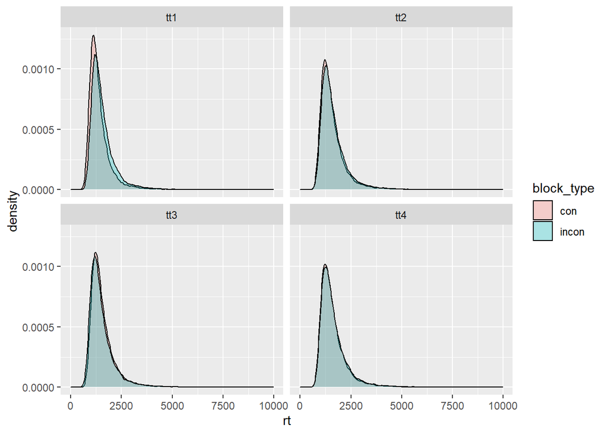

```r
ggplot(data_trimmed, aes(rt, fill = block_type)) +
  geom_density(alpha = 0.3) +
  facet_wrap(~ trial_type)
```

```r
data_trimmed %>%
  group_by(trial_type, block_type) %>%
  summarize(mean = mean(rt, na.rm = TRUE),
            sd = sd(rt, na.rm = TRUE)) %>%
  round_df(0) %>%
  kable() %>%
  kable_styling(bootstrap_options = c("striped", "hover", "condensed"), full_width = FALSE)
```

| trial_type | block_type | mean | sd |
| --- | --- | --- | --- |
| tt1 | con | 1395 | 567 |
| tt1 | incon | 1560 | 637 |
| tt2 | con | 1570 | 658 |
| tt2 | incon | 1633 | 687 |
| tt3 | con | 1560 | 639 |
| tt3 | incon | 1520 | 670 |
| tt4 | con | 1598 | 662 |
| tt4 | incon | 1634 | 695 |

# Bootstrap 95% CIs on D scores

## *D* scores calculated by trial-type

```r
# bootstrapping has a long execution time, so load saved values if they've already been calculated
if(file.exists("models/data_estimates_D.rds")) {

  data_estimates_D <- read_rds("models/data_estimates_D.rds")

} else {

  D_score <- function(data, i) {
    data_with_indexes <- data[i,] # boot function requires data and index
    mean_con <- mean(data_with_indexes$rt[data_with_indexes$block_type == "con"], na.rm = TRUE)
    mean_incon <- mean(data_with_indexes$rt[data_with_indexes$block_type == "incon"], na.rm = TRUE)
    sd <- sd(data_with_indexes$rt, na.rm = TRUE)
    D <- (mean_incon - mean_con) / sd
    return(D)
  }

  bootstrap_D_score <- function(data){

    require(dplyr)
    require(boot)

    fit <-
      boot::boot(data      = data,
                 statistic = D_score,
                 R         = n_boots,
                 sim       = "ordinary",
                 stype     = "i",
                 parallel  = "multicore",
                 ncpus     = parallel::detectCores())

    results <- boot::boot.ci(fit, conf = 0.95, type = c("norm","basic", "perc", "bca"))

    output <-
      tibble(method   = c("normal", "basic", "percent", "bca"),
             estimate = rep(fit$t0, 4),
             ci_lower = c(results$normal[2], results$basic[4], results$percent[4], results$bca[4]),
             ci_upper = c(results$normal[3], results$basic[5], results$percent[5], results$bca[5]))

    return(output)
  }

  # bootstrap D scores
  data_estimates_D <- data_trimmed %>%
    select(unique_id, domain, trial_type, rt, block_type) %>%
    group_by(unique_id, domain, trial_type) %>%
    do(bootstrap_D_score(data = .)) %>%
    ungroup() %>%
    mutate(sig = ifelse((ci_lower < 0 & ci_upper < 0) | (ci_lower > 0 & ci_upper > 0), TRUE, FALSE),
           ci_width = ci_upper - ci_lower) %>%
    round_df(3)

  # save to disk
  write_rds(data_estimates_D, "models/data_estimates_D.rds", compress = "gz")

}
```

## PI scores calculated by trial-type

```r
# bootstrapping has a long execution time, so load saved values if they've already been calculated
if(file.exists("models/data_estimates_PI.rds")) {

  data_estimates_PI <- read_rds("models/data_estimates_PI.rds")

} else {

  # Fast calculation of the A statistic - code from Ruscio (2008) supplementary materials
  PI_score <- function(data, i) {
    data_with_indexes <- data[i,] # boot function requires data and index
    x  <- na.omit(data_with_indexes$rt[data_with_indexes$block_type == "incon"])
    y  <- na.omit(data_with_indexes$rt[data_with_indexes$block_type == "con"])
    nx <- length(x)
    ny <- length(y)
    rx <- sum(rank(c(x, y))[1:nx])
    PI <- (rx / nx - (nx + 1) / 2) / ny
    return(PI)
  }

  bootstrap_PI_score <- function(data){

    require(dplyr)
    require(boot)

    fit <-
      boot::boot(data      = data,
                 statistic = PI_score,
                 R         = n_boots,
                 sim       = "ordinary",
                 stype     = "i",
                 parallel  = "multicore",
                 ncpus     = parallel::detectCores())

    results <- boot::boot.ci(fit, conf = 0.95, type = c("norm","basic", "perc", "bca"))

    output <-
      tibble(method   = c("normal", "basic", "percent", "bca"),
             estimate = rep(fit$t0, 4),
             ci_lower = c(results$normal[2], results$basic[4], results$percent[4], results$bca[4]),
             ci_upper = c(results$normal[3], results$basic[5], results$percent[5], results$bca[5]))

    return(output)
  }

  # bootstrap PI scores
  data_estimates_PI <- data_outliers_removed %>%
    group_by(unique_id, domain, trial_type) %>%
    do(bootstrap_PI_score(data = .)) %>%
    ungroup() %>%
    mutate(sig = ifelse((ci_lower < 0.50 & ci_upper < 0.50) | (ci_lower > 0.50 & ci_upper > 0.50), TRUE, FALSE),
           ci_width = ci_upper - ci_lower) %>%
    round_df(3)

  # save to disk
  write_rds(data_estimates_PI, "models/data_estimates_PI.rds", compress = "gz")

}
```

# CI widths

Widths cant be directly compared between *D* and PI as they have different ranges, so *D* scores only.

Not meta analyzed as extreme skew in data means that residuals are very non-normal, violating assumptions and underestimating MAP estimates. Instead I simply present MAP estimates for each trial type & method, and then domain, trial type, and method.

## Descriptives

```r
full_join(data_estimates_D %>%
            mutate(method = fct_relevel(method, "bca", "basic", "normal", "percent")) %>%
            group_by(method) %>%
            do(point_estimate(.$ci_width, centrality = "MAP")),
          data_estimates_D %>%
            mutate(method = fct_relevel(method, "bca", "basic", "normal", "percent")) %>%
            group_by(method) %>%
            summarize(min = min(ci_width),
                      max = max(ci_width),
                      .groups = "drop"),
          by = "method") %>%
  round_df(2) %>%
  kable() %>%
  kable_styling(bootstrap_options = c("striped", "hover", "condensed"), full_width = FALSE)
```

| method | MAP | min | max |
| --- | --- | --- | --- |
| bca | 1.31 | 0.34 | 1.97 |
| basic | 1.31 | 0.39 | 1.75 |
| normal | 1.32 | 0.37 | 2.15 |
| percent | 1.31 | 0.39 | 1.75 |

```r
data_estimates_D %>%
  mutate(method = fct_relevel(method, "bca", "basic", "normal", "percent")) %>%
  group_by(trial_type, method) %>%
  do(point_estimate(.$ci_width, centrality = "MAP")) %>%
  round_df(2) %>%
  pivot_wider(names_from = method, values_from = MAP) %>%
  kable() %>%
  kable_styling(bootstrap_options = c("striped", "hover", "condensed"), full_width = FALSE)
```

| trial_type | bca | basic | normal | percent |
| --- | --- | --- | --- | --- |
| tt1 | 1.31 | 1.31 | 1.32 | 1.31 |
| tt2 | 1.31 | 1.31 | 1.32 | 1.31 |
| tt3 | 1.31 | 1.31 | 1.32 | 1.31 |
| tt4 | 1.31 | 1.31 | 1.32 | 1.31 |

```r
data_estimates_D %>%
  mutate(method = fct_relevel(method, "bca", "basic", "normal", "percent")) %>%
  summarize(min_Dscore = min(estimate),
            max_Dscore = max(estimate)) %>%
  mutate(range_Dscore = max_Dscore - min_Dscore) %>%
  round_df(2)
```

```
## # A tibble: 1 x 3
##   min_Dscore max_Dscore range_Dscore
##        <dbl>      <dbl>        <dbl>
## 1      -1.27       1.53          2.8
```

## Plot by domain

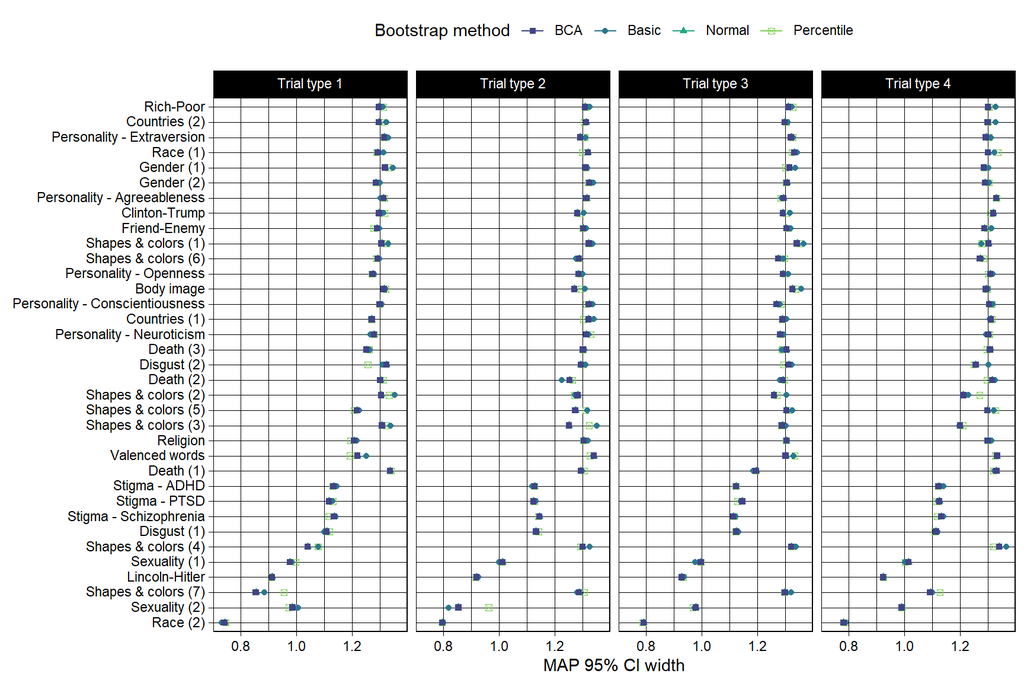

```r
data_ci_width_map_D <- data_estimates_D %>%
  group_by(domain, trial_type, method) %>%
  #summarize(median = median(ci_width), .groups = "drop") %>%
  do(point_estimate(.$ci_width, centrality = "MAP")) %>%
  ungroup() %>%
  mutate(method = fct_relevel(method, "bca", "basic", "normal", "percent"),
         method = fct_rev(method),
         trial_type = case_when(trial_type == "tt1" ~ "Trial type 1",
                                trial_type == "tt2" ~ "Trial type 2",
                                trial_type == "tt3" ~ "Trial type 3",
                                trial_type == "tt4" ~ "Trial type 4"),
         trial_type = fct_relevel(trial_type, "Trial type 1", "Trial type 2", "Trial type 3", "Trial type 4")) %>%
  mutate(domain = fct_reorder(domain, MAP, .fun = min)) %>%
  arrange(domain)

# save to disk
write_rds(data_ci_width_map_D, "models/data_ci_width_map_D.rds")

# plot
ggplot(data_ci_width_map_D, aes(MAP, domain, color = method, shape = method)) +
  geom_line() +
  geom_point() +
  scale_shape_manual(labels = c("BCA", "Basic", "Normal", "Percentile"), values = c(15, 16, 17, 7)) +
  scale_color_viridis_d(begin = 0.2, end = 0.8, labels = c("BCA", "Basic", "Normal", "Percentile")) +
  mdthemes::md_theme_linedraw() +
  facet_wrap(~ trial_type, ncol = 4, nrow = 1) +
  labs(x = "MAP 95% CI width",
       y = "",
       color = "Bootstrap method",
       shape = "Bootstrap method") +
  theme(legend.position = "top")
```

# Proportion different from zero

## Calculate scores

```r
data_diff_zero <-
  bind_rows(mutate(data_estimates_D, DV_type = "*D* scores"),
            mutate(data_estimates_PI, DV_type = "PI scores")) %>%
  mutate(domain = as.factor(domain),
         method = fct_relevel(method, "bca", "basic", "normal", "percent"),
         method = fct_rev(method),
         trial_type = case_when(trial_type == "tt1" ~ "Trial type 1",
                                trial_type == "tt2" ~ "Trial type 2",
                                trial_type == "tt3" ~ "Trial type 3",
                                trial_type == "tt4" ~ "Trial type 4"),
         trial_type = fct_relevel(trial_type, "Trial type 1", "Trial type 2", "Trial type 3", "Trial type 4")) %>%
  group_by(domain, trial_type, method, DV_type) %>%
  summarize(proportion_diff_zero = mean(sig),
            variance = plotrix::std.error(sig)^2,
            .groups = "drop") %>%
  mutate(variance = ifelse(variance == 0, 0.000001, variance))  # model cannot be run on zero variance, so offset by a miniscule amount

# save to disk
write_rds(data_diff_zero, "models/data_diff_zero.rds")
```

## Plots

### By trial type

Data is split by domain and method but this is not shown in the plot. All domains are collated, and only the BCA method is plotted.

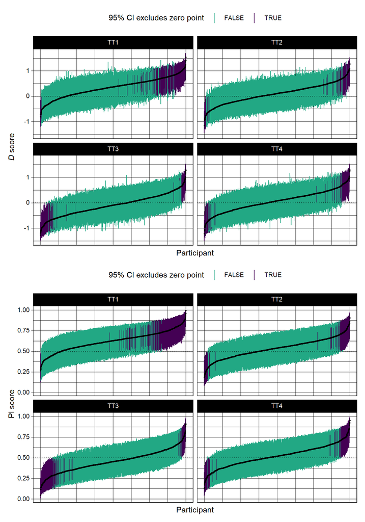

```r
p_dist_D <- data_estimates_D %>%
  filter(method == "bca") %>%
  arrange(estimate) %>%
  group_by(trial_type) %>%
  mutate(ordered_id = row_number()/n()) %>%
  ungroup() %>%
  mutate(trial_type = case_when(trial_type == "tt1" ~ "TT1",
                                trial_type == "tt2" ~ "TT2",
                                trial_type == "tt3" ~ "TT3",
                                trial_type == "tt4" ~ "TT4"),
         trial_type = fct_relevel(trial_type, "TT1", "TT2", "TT3", "TT4")) %>%
  ggplot() +
  geom_linerange(aes(x = ordered_id, ymin = ci_lower, ymax = ci_upper, color = sig),
                 alpha = 1) +
  geom_point(aes(ordered_id, estimate), size = 0.5) +
  geom_hline(yintercept = 0, linetype = "dotted") +
  mdthemes::md_theme_linedraw() +
  theme(axis.text.x = element_blank(),
        axis.ticks.x = element_blank(),
        legend.position = "top") +
  scale_color_viridis_d(end = 0.6, direction = -1) +
  xlab("Participant") +
  ylab("*D* score") +
  labs(color = "95% CI excludes zero point") +
  facet_wrap(~ trial_type)

p_dist_PI <- data_estimates_PI %>%
  filter(method == "bca") %>%
  arrange(estimate) %>%
  group_by(trial_type) %>%
  mutate(ordered_id = row_number()/n()) %>%
  ungroup() %>%
  mutate(trial_type = case_when(trial_type == "tt1" ~ "TT1",
                                trial_type == "tt2" ~ "TT2",
                                trial_type == "tt3" ~ "TT3",
                                trial_type == "tt4" ~ "TT4"),
         trial_type = fct_relevel(trial_type, "TT1", "TT2", "TT3", "TT4")) %>%
  ggplot() +
  geom_linerange(aes(x = ordered_id, ymin = ci_lower, ymax = ci_upper, color = sig),
                 alpha = 1) +
  geom_point(aes(ordered_id, estimate), size = 0.5) +
  geom_hline(yintercept = 0.50, linetype = "dotted") +
  mdthemes::md_theme_linedraw() +
  theme(axis.text.x = element_blank(),
        axis.ticks.x = element_blank(),
        legend.position = "top") +
  scale_color_viridis_d(end = 0.6, direction = -1) +
  xlab("Participant") +
  ylab("PI score") +
  labs(color = "95% CI excludes zero point") +
  facet_wrap(~ trial_type)

p_dist_D + p_dist_PI + plot_layout(ncol = 1, nrow = 2)  # , guides = "collect"
```

### By domain

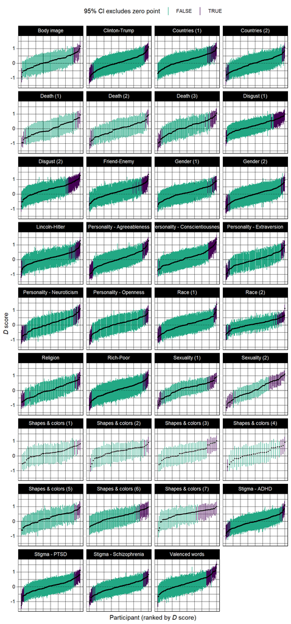

```r
data_estimates_D %>%
  filter(method == "bca") %>%
  arrange(estimate) %>%
  group_by(domain) %>%
  mutate(ordered_id = row_number()/n()) %>%
  ungroup() %>%
  ggplot() +
  geom_linerange(aes(x = ordered_id, ymin = ci_lower, ymax = ci_upper, color = sig),
                 alpha = 1) +
  geom_point(aes(ordered_id, estimate), size = 0.5) +
  geom_hline(yintercept = 0, linetype = "dotted") +
  mdthemes::md_theme_linedraw() +
  theme(axis.text.x = element_blank(),
        axis.ticks.x = element_blank(),
        legend.position = "top") +
  scale_color_viridis_d(end = 0.6, direction = -1) +
  xlab("Participant (ranked by *D* score)") +
  ylab("*D* score") +
  labs(color = "95% CI excludes zero point") +
  facet_wrap(~ domain, ncol = 4)
```

### By domain and trial type

32X35 cells

```r
data_diff_zero %>%
  filter(method == "bca") %>%
  mutate(DV_type = case_when(DV_type == "*D* scores" ~ "D",
                             DV_type == "PI scores" ~ "PI")) %>%
  select(-variance) %>%
  pivot_wider(names_from = c(trial_type, DV_type, method),
              values_from = proportion_diff_zero) %>%
  round_df(2) %>%
  janitor::clean_names() %>%
  kable() %>%
  kable_styling(bootstrap_options = c("striped", "hover", "condensed"), full_width = FALSE)
```

| domain | trial_type_1_d_bca | trial_type_1_pi_bca | trial_type_2_d_bca | trial_type_2_pi_bca | trial_type_3_d_bca | trial_type_3_pi_bca | trial_type_4_d_bca | trial_type_4_pi_bca |
| --- | --- | --- | --- | --- | --- | --- | --- | --- |
| Body image | 0.17 | 0.17 | 0.09 | 0.09 | 0.04 | 0.13 | 0.22 | 0.13 |
| Clinton-Trump | 0.20 | 0.25 | 0.08 | 0.07 | 0.18 | 0.18 | 0.08 | 0.05 |
| Countries (1) | 0.21 | 0.34 | 0.15 | 0.19 | 0.13 | 0.08 | 0.00 | 0.02 |
| Countries (2) | 0.08 | 0.14 | 0.12 | 0.20 | 0.08 | 0.12 | 0.06 | 0.06 |
| Death (1) | 0.06 | 0.06 | 0.12 | 0.12 | 0.29 | 0.18 | 0.06 | 0.06 |
| Death (2) | 0.10 | 0.10 | 0.10 | 0.10 | 0.10 | 0.15 | 0.10 | 0.20 |
| Death (3) | 0.38 | 0.31 | 0.15 | 0.19 | 0.12 | 0.08 | 0.15 | 0.19 |
| Disgust (1) | 0.19 | 0.24 | 0.11 | 0.11 | 0.30 | 0.24 | 0.32 | 0.30 |
| Disgust (2) | 0.23 | 0.26 | 0.21 | 0.23 | 0.12 | 0.07 | 0.33 | 0.35 |
| Friend-Enemy | 0.31 | 0.36 | 0.18 | 0.18 | 0.04 | 0.09 | 0.08 | 0.11 |
| Gender (1) | 0.07 | 0.10 | 0.00 | 0.05 | 0.10 | 0.07 | 0.17 | 0.20 |
| Gender (2) | 0.19 | 0.17 | 0.03 | 0.03 | 0.17 | 0.18 | 0.06 | 0.03 |
| Lincoln-Hitler | 0.29 | 0.32 | 0.11 | 0.11 | 0.08 | 0.11 | 0.11 | 0.11 |
| Personality - Agreeableness | 0.31 | 0.31 | 0.13 | 0.21 | 0.05 | 0.13 | 0.15 | 0.15 |
| Personality - Conscientiousness | 0.38 | 0.41 | 0.03 | 0.00 | 0.10 | 0.10 | 0.10 | 0.21 |
| Personality - Extraversion | 0.15 | 0.15 | 0.09 | 0.06 | 0.21 | 0.21 | 0.03 | 0.00 |
| Personality - Neuroticism | 0.25 | 0.28 | 0.06 | 0.03 | 0.22 | 0.16 | 0.16 | 0.16 |
| Personality - Openness | 0.12 | 0.09 | 0.12 | 0.06 | 0.06 | 0.03 | 0.15 | 0.12 |
| Race (1) | 0.16 | 0.18 | 0.02 | 0.02 | 0.16 | 0.16 | 0.09 | 0.09 |
| Race (2) | 0.36 | 0.43 | 0.07 | 0.11 | 0.14 | 0.20 | 0.11 | 0.09 |
| Religion | 0.17 | 0.17 | 0.10 | 0.07 | 0.17 | 0.20 | 0.13 | 0.07 |
| Rich-Poor | 0.18 | 0.25 | 0.11 | 0.08 | 0.12 | 0.19 | 0.07 | 0.11 |
| Sexuality (1) | 0.42 | 0.50 | 0.04 | 0.15 | 0.27 | 0.35 | 0.15 | 0.12 |
| Sexuality (2) | 0.58 | 0.58 | 0.37 | 0.37 | 0.42 | 0.47 | 0.26 | 0.37 |
| Shapes & colors (1) | 0.18 | 0.27 | 0.18 | 0.18 | 0.00 | 0.09 | 0.00 | 0.00 |
| Shapes & colors (2) | 0.18 | 0.36 | 0.09 | 0.09 | 0.00 | 0.00 | 0.09 | 0.18 |
| Shapes & colors (3) | 0.10 | 0.10 | 0.10 | 0.10 | 0.30 | 0.30 | 0.20 | 0.30 |
| Shapes & colors (4) | 0.25 | 0.38 | 0.00 | 0.00 | 0.00 | 0.12 | 0.25 | 0.12 |
| Shapes & colors (5) | 0.36 | 0.50 | 0.00 | 0.05 | 0.00 | 0.09 | 0.00 | 0.09 |
| Shapes & colors (6) | 0.23 | 0.23 | 0.12 | 0.19 | 0.08 | 0.08 | 0.27 | 0.31 |
| Shapes & colors (7) | 0.57 | 0.50 | 0.14 | 0.21 | 0.29 | 0.29 | 0.36 | 0.36 |
| Stigma - ADHD | 0.16 | 0.27 | 0.08 | 0.08 | 0.13 | 0.16 | 0.11 | 0.18 |
| Stigma - PTSD | 0.30 | 0.31 | 0.11 | 0.07 | 0.09 | 0.20 | 0.11 | 0.09 |
| Stigma - Schizophrenia | 0.13 | 0.22 | 0.11 | 0.11 | 0.22 | 0.30 | 0.15 | 0.13 |
| Valenced words | 0.41 | 0.49 | 0.14 | 0.11 | 0.08 | 0.14 | 0.08 | 0.11 |

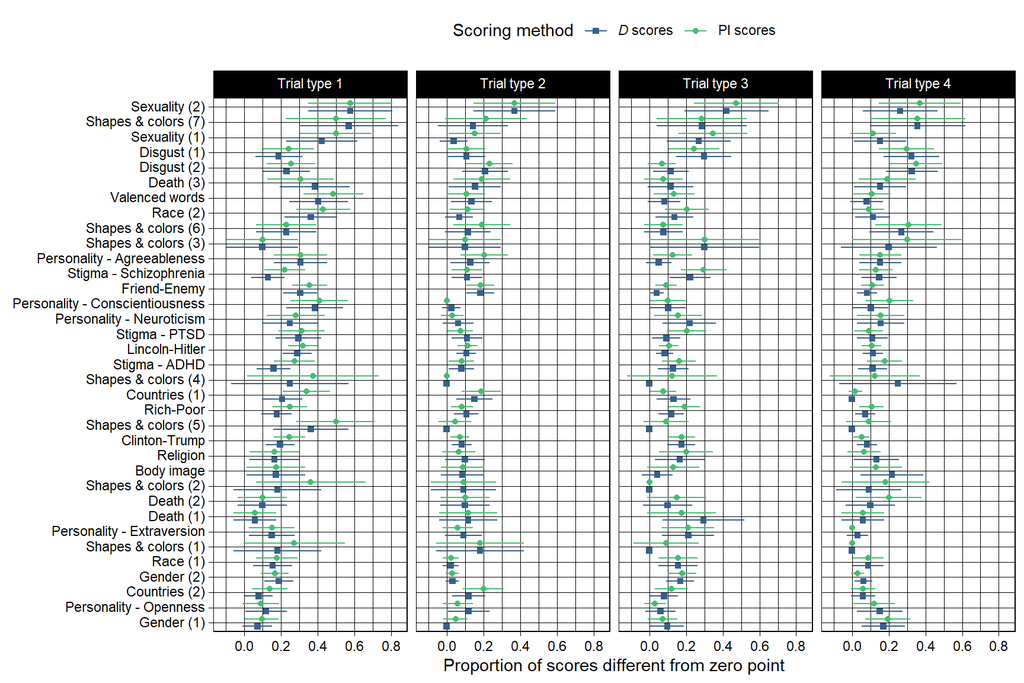

```r
data_diff_zero %>%
  filter(method == "bca") %>%
  mutate(domain = fct_reorder(domain, proportion_diff_zero, .fun = mean)) %>%
  ggplot(aes(proportion_diff_zero, domain, color = DV_type, shape = DV_type)) +
  geom_linerangeh(aes(xmin = proportion_diff_zero - sqrt(variance)*1.96,
                      xmax = proportion_diff_zero + sqrt(variance)*1.96),
                  position = position_dodge(width = 1)) +
  geom_point(position = position_dodge(width = 1)) +
  scale_shape_manual(labels = c("*D* scores", "PI scores"), values = c(15, 16)) +
  scale_color_viridis_d(begin = 0.3, end = 0.7, labels = c("*D* scores", "PI scores")) +
  mdthemes::md_theme_linedraw() +
  facet_wrap(~ trial_type, ncol = 4) +
  labs(x = "Proportion of scores different from zero point",
       y = "",
       color = "Scoring method",
       shape = "Scoring method") +
  theme(legend.position = "top")
```

## Model

### Compare scoring methods

```r
# fit model
fit_diff_zero_scoring <-
  data_diff_zero %>%
  filter(method == "bca") %>%
  lmer(proportion_diff_zero ~ 1 + trial_type * DV_type + (trial_type | domain),
       weights = 1/variance,
       data = .)

# results table
tab_model(fit_diff_zero_scoring,
          string.p = "p (corrected)",
          ci.hyphen = ", ",
          #emph.p = FALSE,
          p.adjust = "holm")
```

|  | proportion diff zero |  |  |
| --- | --- | --- | --- |
| Predictors | Estimates | CI | p (corrected) |
| (Intercept) | 0.24 | 0.19, 0.28 | **<0.001** |
| trial_type [Trial type 2] | -0.14 | -0.18, -0.09 | **<0.001** |
| trial_type [Trial type 3] | -0.10 | -0.15, -0.05 | **<0.001** |
| trial_type [Trial type 4] | -0.11 | -0.15, -0.06 | **<0.001** |
| DV_type PI scores | 0.04 | 0.02, 0.06 | **0.001** |
| trial_type [Trial type 2] * DV_type PI scores | -0.04 | -0.06, -0.02 | **0.001** |
| trial_type [Trial type 3] * DV_type PI scores | -0.04 | -0.06, -0.02 | **0.001** |
| trial_type [Trial type 4] * DV_type PI scores | -0.04 | -0.06, -0.02 | **0.001** |
| Random Effects |  |  |  |
| σ<sup>2</sup> | 0.42 |  |  |
| τ<sub>00</sub> <sub>domain</sub> | 0.01 |  |  |
| τ<sub>11</sub> <sub>domain.trial_typeTrial type 2</sub> | 0.01 |  |  |
| τ<sub>11</sub> <sub>domain.trial_typeTrial type 3</sub> | 0.02 |  |  |
| τ<sub>11</sub> <sub>domain.trial_typeTrial type 4</sub> | 0.02 |  |  |
| ρ<sub>01</sub> | -0.85 |  |  |
|  | -0.76 |  |  |
|  | -0.76 |  |  |
| ICC | 0.02 |  |  |
| N <sub>domain</sub> | 35 |  |  |
| Observations | 280 |  |  |
| Marginal R<sup>2</sup> / Conditional R<sup>2</sup> | 0.008 / 0.029 |  |  |

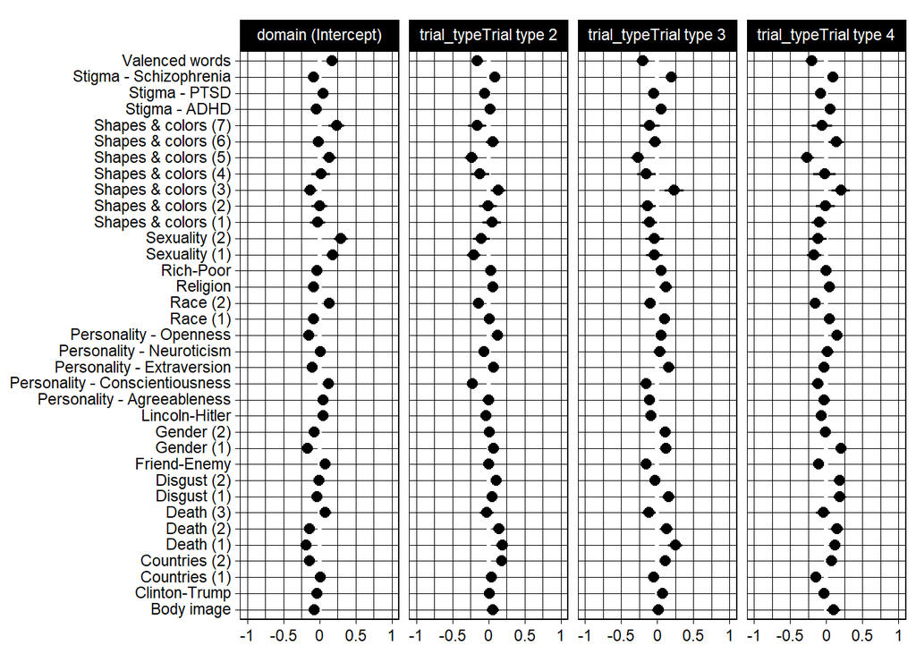

```r
plot_model(fit_diff_zero_scoring,
           colors = "bw",
           type = "re") +
  mdthemes::md_theme_linedraw() +
  ggtitle("")
```

```r
summary(fit_diff_zero_scoring)
```

```
## Linear mixed model fit by REML ['lmerMod']
## Formula: proportion_diff_zero ~ 1 + trial_type * DV_type + (trial_type |
##     domain)
##    Data: .
## Weights: 1/variance
##
## REML criterion at convergence: -669.1
##
## Scaled residuals:
##      Min       1Q   Median       3Q      Max
## -1.45476 -0.29086  0.08845  0.66821  2.23317
##
## Random effects:
##  Groups   Name                   Variance Std.Dev. Corr
##  domain   (Intercept)            0.01478  0.1216
##           trial_typeTrial type 2 0.01408  0.1187   -0.85
##           trial_typeTrial type 3 0.01863  0.1365   -0.76  0.74
##           trial_typeTrial type 4 0.01698  0.1303   -0.76  0.78  0.73
##  Residual                        0.42015  0.6482
## Number of obs: 280, groups:  domain, 35
##
## Fixed effects:
##                                          Estimate Std. Error t value
## (Intercept)                              0.235972   0.021957  10.747
## trial_typeTrial type 2                  -0.136757   0.021896  -6.246
## trial_typeTrial type 3                  -0.101477   0.024767  -4.097
## trial_typeTrial type 4                  -0.107243   0.023845  -4.498
## DV_typePI scores                         0.036650   0.009736   3.764
## trial_typeTrial type 2:DV_typePI scores -0.036574   0.009778  -3.740
## trial_typeTrial type 3:DV_typePI scores -0.036282   0.009779  -3.710
## trial_typeTrial type 4:DV_typePI scores -0.036576   0.009778  -3.741
##
## Correlation of Fixed Effects:
##             (Intr) tr_Tt2 tr_Tt3 tr_Tt4 DV_PIs t_Tt2s t_Tt3s
## trl_typTrt2 -0.854
## trl_typTrt3 -0.770  0.743
## trl_typTrt4 -0.770  0.775  0.731
## DV_typPIscr -0.210  0.211  0.187  0.194
## t_Tt2:DV_Ps  0.210 -0.212 -0.186 -0.193 -0.996
## t_Tt3:DV_Ps  0.209 -0.210 -0.187 -0.193 -0.996  0.991
## t_Tt4:DV_Ps  0.210 -0.210 -0.186 -0.195 -0.996  0.991  0.991
```

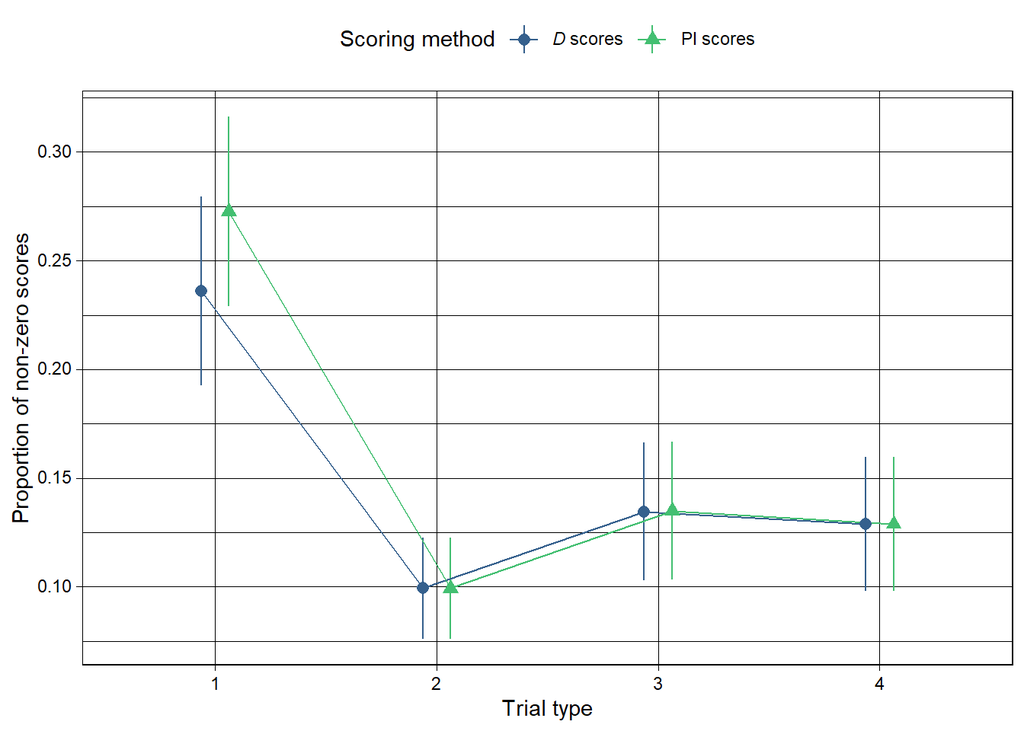

```r
# extract marginal means
results_emm_diff_zero_scoring <-
  summary(emmeans(fit_diff_zero_scoring, ~ DV_type | trial_type)) %>%
  select(DV_type, trial_type, estimate = emmean, ci_lower = lower.CL, ci_upper = upper.CL) %>%
  mutate(trial_type = fct_relevel(trial_type, "tt1", "tt2", "tt3", "tt4"))

# save to disk
write_rds(results_emm_diff_zero_scoring, "models/results_emm_diff_zero_scoring.rds")

ggplot(results_emm_diff_zero_scoring, aes(trial_type, estimate, color = DV_type, shape = DV_type, group = DV_type)) +
  geom_linerange(aes(ymin = ci_lower, ymax = ci_upper), position = position_dodge(width = dodge_width)) +
  geom_line(position = position_dodge(width = dodge_width)) +
  geom_point(position = position_dodge(width = dodge_width), size = 2.5) +
  mdthemes::md_theme_linedraw() +
  scale_x_discrete(labels = c("Trial type 1" = "1", "Trial type 2" = "2", "Trial type 3" = "3", "Trial type 4" = "4")) +
  scale_color_viridis_d(begin = 0.3, end = 0.7, labels = c("*D* scores", "PI scores")) +
  labs(shape = "Scoring method",
       color = "Scoring method",
       x = "Trial type",
       y = "Proportion of non-zero scores") +
  theme(legend.position = "top")
```

```r
# tests
emmeans(fit_diff_zero_scoring, list(pairwise ~ DV_type | trial_type), adjust = "bonferroni")
```

```
## $`emmeans of DV_type | trial_type`
## trial_type = Trial type 1:
##  DV_type    emmean     SE    df lower.CL upper.CL
##  *D* scores 0.2360 0.0222  6623   0.1925    0.279
##  PI scores  0.2726 0.0223  6625   0.2289    0.316
##
## trial_type = Trial type 2:
##  DV_type    emmean     SE    df lower.CL upper.CL
##  *D* scores 0.0992 0.0119 25285   0.0759    0.123
##  PI scores  0.0993 0.0119 25290   0.0759    0.123
##
## trial_type = Trial type 3:
##  DV_type    emmean     SE    df lower.CL upper.CL
##  *D* scores 0.1345 0.0162 13968   0.1028    0.166
##  PI scores  0.1349 0.0162 13970   0.1032    0.167
##
## trial_type = Trial type 4:
##  DV_type    emmean     SE    df lower.CL upper.CL
##  *D* scores 0.1287 0.0157 13405   0.0979    0.160
##  PI scores  0.1288 0.0157 13406   0.0980    0.160
##
## Degrees-of-freedom method: kenward-roger
## Confidence level used: 0.95
##
## $`pairwise differences of DV_type | trial_type`
## trial_type = Trial type 1:
##  2                          estimate       SE           df t.ratio p.value
##  (*D* scores) - PI scores -0.0366504 0.009737      8979469 -3.764  0.0002
##
## trial_type = Trial type 2:
##  2                          estimate       SE           df t.ratio p.value
##  (*D* scores) - PI scores -0.0000768 0.000906 119717151791 -0.085  0.9325
##
## trial_type = Trial type 3:
##  2                          estimate       SE           df t.ratio p.value
##  (*D* scores) - PI scores -0.0003681 0.000910 117400475158 -0.404  0.6859
##
## trial_type = Trial type 4:
##  2                          estimate       SE           df t.ratio p.value
##  (*D* scores) - PI scores -0.0000744 0.000906 119551896105 -0.082  0.9346
##
## Degrees-of-freedom method: kenward-roger
```

```r
emmeans(fit_diff_zero_scoring, list(pairwise ~ trial_type | DV_type), adjust = "bonferroni")
```

```
## $`emmeans of trial_type | DV_type`
## DV_type = *D* scores:
##  trial_type   emmean     SE    df lower.CL upper.CL
##  Trial type 1 0.2360 0.0222  6623   0.1925    0.279
##  Trial type 2 0.0992 0.0119 25285   0.0759    0.123
##  Trial type 3 0.1345 0.0162 13968   0.1028    0.166
##  Trial type 4 0.1287 0.0157 13405   0.0979    0.160
##
## DV_type = PI scores:
##  trial_type   emmean     SE    df lower.CL upper.CL
##  Trial type 1 0.2726 0.0223  6625   0.2289    0.316
##  Trial type 2 0.0993 0.0119 25290   0.0759    0.123
##  Trial type 3 0.1349 0.0162 13970   0.1032    0.167
##  Trial type 4 0.1288 0.0157 13406   0.0980    0.160
##
## Degrees-of-freedom method: kenward-roger
## Confidence level used: 0.95
##
## $`pairwise differences of trial_type | DV_type`
## DV_type = *D* scores:
##  2                           estimate     SE    df t.ratio p.value
##  Trial type 1 - Trial type 2  0.13676 0.0220 13560  6.203  <.0001
##  Trial type 1 - Trial type 3  0.10148 0.0249 13825  4.069  0.0003
##  Trial type 1 - Trial type 4  0.10724 0.0240 15085  4.468  <.0001
##  Trial type 2 - Trial type 3 -0.03528 0.0170 46995 -2.075  0.2282
##  Trial type 2 - Trial type 4 -0.02951 0.0155 61753 -1.904  0.3416
##  Trial type 3 - Trial type 4  0.00577 0.0179 50980  0.322  1.0000
##
## DV_type = PI scores:
##  2                           estimate     SE    df t.ratio p.value
##  Trial type 1 - Trial type 2  0.17333 0.0222 13509  7.822  <.0001
##  Trial type 1 - Trial type 3  0.13776 0.0250 13775  5.502  <.0001
##  Trial type 1 - Trial type 4  0.14382 0.0241 15024  5.967  <.0001
##  Trial type 2 - Trial type 3 -0.03557 0.0170 46993 -2.091  0.2191
##  Trial type 2 - Trial type 4 -0.02951 0.0155 61760 -1.904  0.3419
##  Trial type 3 - Trial type 4  0.00606 0.0179 50980  0.338  1.0000
##
## Degrees-of-freedom method: kenward-roger
## P value adjustment: bonferroni method for 6 tests
```

### Compare CI bootstrapping methods

```r
# fit model
fit_diff_zero_method <-
  data_diff_zero %>%
  filter(DV_type == "*D* scores") %>%
  lmer(proportion_diff_zero ~ 1 + trial_type * method + (trial_type | domain),
       weights = 1/variance,
       data = .)

# results table
tab_model(fit_diff_zero_method,
          string.p = "p (corrected)",
          ci.hyphen = ", ",
          #emph.p = FALSE,
          p.adjust = "holm")
```

|  | proportion diff zero |  |  |
| --- | --- | --- | --- |
| Predictors | Estimates | CI | p (corrected) |
| (Intercept) | 0.31 | 0.26, 0.35 | **<0.001** |
| trial_type [Trial type 2] | -0.19 | -0.24, -0.15 | **<0.001** |
| trial_type [Trial type 3] | -0.16 | -0.22, -0.10 | **<0.001** |
| trial_type [Trial type 4] | -0.13 | -0.18, -0.08 | **<0.001** |
| method [normal] | 0.03 | 0.01, 0.05 | **0.007** |
| method [basic] | 0.06 | 0.05, 0.08 | **<0.001** |
| method [bca] | -0.07 | -0.08, -0.05 | **<0.001** |
| trial_type [Trial type 2] * method [normal] | 0.03 | 0.00, 0.05 | 0.068 |
| trial_type [Trial type 3] * method [normal] | 0.04 | 0.01, 0.06 | **0.010** |
| trial_type [Trial type 4] * method [normal] | -0.01 | -0.03, 0.02 | 0.996 |
| trial_type [Trial type 2] * method [basic] | 0.03 | 0.01, 0.06 | **0.024** |
| trial_type [Trial type 3] * method [basic] | 0.04 | 0.02, 0.06 | **0.009** |
| trial_type [Trial type 4] * method [basic] | -0.01 | -0.03, 0.02 | 0.996 |
| trial_type [Trial type 2] * method [bca] | 0.07 | 0.05, 0.08 | **<0.001** |
| trial_type [Trial type 3] * method [bca] | 0.07 | 0.05, 0.08 | **<0.001** |
| trial_type [Trial type 4] * method [bca] | 0.02 | -0.00, 0.04 | 0.151 |
| Random Effects |  |  |  |
| σ<sup>2</sup> | 0.33 |  |  |
| τ<sub>00</sub> <sub>domain</sub> | 0.02 |  |  |
| τ<sub>11</sub> <sub>domain.trial_typeTrial type 2</sub> | 0.02 |  |  |
| τ<sub>11</sub> <sub>domain.trial_typeTrial type 3</sub> | 0.03 |  |  |
| τ<sub>11</sub> <sub>domain.trial_typeTrial type 4</sub> | 0.02 |  |  |
| ρ<sub>01</sub> | -0.84 |  |  |
|  | -0.78 |  |  |
|  | -0.71 |  |  |
| ICC | 0.03 |  |  |
| N <sub>domain</sub> | 35 |  |  |
| Observations | 560 |  |  |
| Marginal R<sup>2</sup> / Conditional R<sup>2</sup> | 0.016 / 0.048 |  |  |

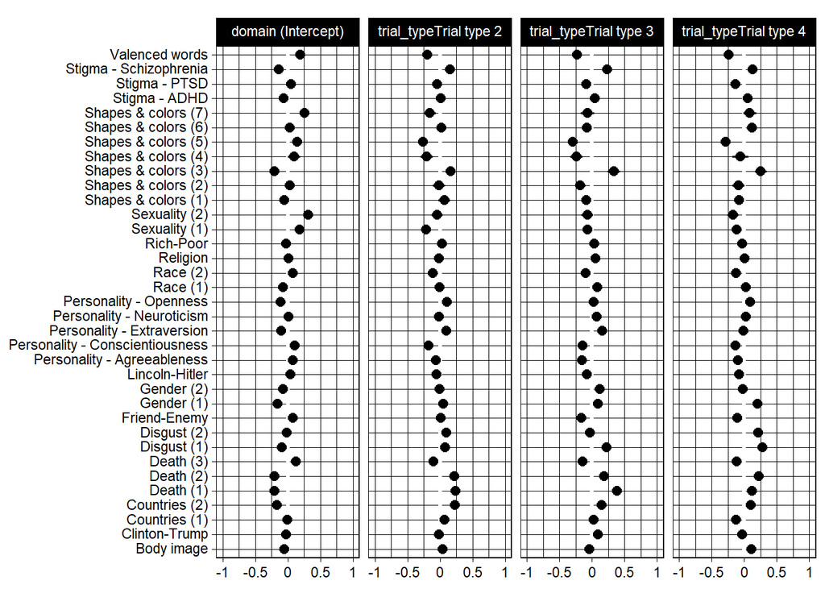

```r
plot_model(fit_diff_zero_method,
           colors = "bw",
           type = "re") +
  mdthemes::md_theme_linedraw() +
  ggtitle("")
```

```r
summary(fit_diff_zero_method)
```

```
## Linear mixed model fit by REML ['lmerMod']
## Formula: proportion_diff_zero ~ 1 + trial_type * method + (trial_type |
##     domain)
##    Data: .
## Weights: 1/variance
##
## REML criterion at convergence: -1517.3
##
## Scaled residuals:
##     Min      1Q  Median      3Q     Max
## -2.2582 -0.3883  0.1004  0.5687  3.1523
##
## Random effects:
##  Groups   Name                   Variance Std.Dev. Corr
##  domain   (Intercept)            0.01746  0.1321
##           trial_typeTrial type 2 0.01681  0.1296   -0.84
##           trial_typeTrial type 3 0.02651  0.1628   -0.78  0.80
##           trial_typeTrial type 4 0.02095  0.1447   -0.71  0.71  0.73
##  Residual                        0.33022  0.5746
## Number of obs: 560, groups:  domain, 35
##
## Fixed effects:
##                                      Estimate Std. Error t value
## (Intercept)                          0.308929   0.023434  13.183
## trial_typeTrial type 2              -0.192112   0.023320  -8.238
## trial_typeTrial type 3              -0.160350   0.028679  -5.591
## trial_typeTrial type 4              -0.127594   0.026081  -4.892
## methodnormal                         0.031708   0.009493   3.340
## methodbasic                          0.064431   0.009627   6.693
## methodbca                           -0.067421   0.008871  -7.600
## trial_typeTrial type 2:methodnormal  0.027250   0.011405   2.389
## trial_typeTrial type 3:methodnormal  0.036709   0.011692   3.140
## trial_typeTrial type 4:methodnormal -0.008180   0.012075  -0.677
## trial_typeTrial type 2:methodbasic   0.033191   0.011771   2.820
## trial_typeTrial type 3:methodbasic   0.038777   0.012038   3.221
## trial_typeTrial type 4:methodbasic  -0.005323   0.012405  -0.429
## trial_typeTrial type 2:methodbca     0.066640   0.008908   7.481
## trial_typeTrial type 3:methodbca     0.066750   0.008908   7.493
## trial_typeTrial type 4:methodbca     0.021179   0.010817   1.958
```

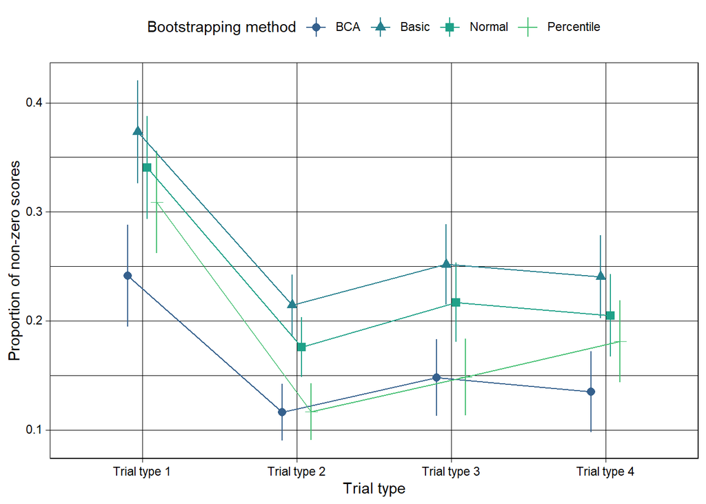

```r
# extract marginal means
results_emm_diff_zero_method <-
  summary(emmeans(fit_diff_zero_method, ~ method | trial_type)) %>%
  select(method, trial_type, estimate = emmean, ci_lower = lower.CL, ci_upper = upper.CL) %>%
  mutate(trial_type = fct_relevel(trial_type, "tt1", "tt2", "tt3", "tt4"),
         method = fct_relevel(method, "bca", "basic", "normal", "percent"))

# save to disk
write_rds(results_emm_diff_zero_method, "models/results_emm_diff_zero_method.rds")
results_emm_diff_zero_method <- read_rds("models/results_emm_diff_zero_method.rds")

ggplot(results_emm_diff_zero_method, aes(trial_type, estimate, color = method, shape = method, group = method)) +
  geom_linerange(aes(ymin = ci_lower, ymax = ci_upper), position = position_dodge(width = dodge_width)) +
  geom_line(position = position_dodge(width = dodge_width)) +
  geom_point(position = position_dodge(width = dodge_width), size = 2.5) +
  mdthemes::md_theme_linedraw() +
  scale_x_discrete(labels = c("tt1" = "1", "tt2" = "2", "tt3" = "3", "tt4" = "4")) +
  scale_shape_discrete(labels = c("BCA", "Basic", "Normal", "Percentile")) +
  scale_color_viridis_d(begin = 0.3, end = 0.7, labels = c("BCA", "Basic", "Normal", "Percentile")) +
  labs(shape = "Bootstrapping method",
       color = "Bootstrapping method",
       x = "Trial type",
       y = "Proportion of non-zero scores") +
  theme(legend.position = "top")
```

```r
# tests
emmeans(fit_diff_zero_method, list(pairwise ~ method | trial_type), adjust = "bonferroni")
```

```
## $`emmeans of method | trial_type`
## trial_type = Trial type 1:
##  method  emmean     SE   df lower.CL upper.CL
##  percent  0.309 0.0240 1080   0.2619    0.356
##  normal   0.341 0.0240 1086   0.2935    0.388
##  basic    0.373 0.0241 1091   0.3262    0.421
##  bca      0.242 0.0238 1063   0.1949    0.288
##
## trial_type = Trial type 2:
##  method  emmean     SE   df lower.CL upper.CL
##  percent  0.117 0.0132 3221   0.0909    0.143
##  normal   0.176 0.0140 3887   0.1483    0.203
##  basic    0.214 0.0142 4041   0.1866    0.242
##  bca      0.116 0.0132 3216   0.0901    0.142
##
## trial_type = Trial type 3:
##  method  emmean     SE   df lower.CL upper.CL
##  percent  0.149 0.0179 1946   0.1135    0.184
##  normal   0.217 0.0186 2179   0.1806    0.253
##  basic    0.252 0.0187 2219   0.2151    0.288
##  bca      0.148 0.0179 1945   0.1128    0.183
##
## trial_type = Trial type 4:
##  method  emmean     SE   df lower.CL upper.CL
##  percent  0.181 0.0191 1673   0.1438    0.219
##  normal   0.205 0.0193 1704   0.1671    0.243
##  basic    0.240 0.0194 1734   0.2024    0.278
##  bca      0.135 0.0189 1619   0.0981    0.172
##
## Degrees-of-freedom method: kenward-roger
## Confidence level used: 0.95
##
## $`pairwise differences of method | trial_type`
## trial_type = Trial type 1:
##  2                 estimate       SE           df t.ratio p.value
##  percent - normal -0.031708 0.009494     18390245  -3.340 0.0050
##  percent - basic  -0.064431 0.009627     17350004  -6.693 <.0001
##  percent - bca     0.067421 0.008872     23853769   7.600 <.0001
##  normal - basic   -0.032723 0.009766     16426026  -3.351 0.0048
##  normal - bca      0.099129 0.009032     22034113  10.975 <.0001
```

[output cut: 16 more lines]

```
##  normal - basic   -0.034791 0.008684     26144671  -4.006 0.0004
##  normal - bca      0.069088 0.006816     38292903  10.136 <.0001
##  basic - bca       0.103879 0.007219     29717312  14.390 <.0001
##
## trial_type = Trial type 4:
##  2                 estimate       SE           df t.ratio p.value
##  percent - normal -0.023528 0.007461     47629728  -3.153 0.0097
##  percent - basic  -0.059108 0.007823     38385759  -7.555 <.0001
##  percent - bca     0.046242 0.006189     94703973   7.472 <.0001
##  normal - basic   -0.035580 0.008115     34205152  -4.384 0.0001
##  normal - bca      0.069770 0.006756     62785105  10.326 <.0001
##  basic - bca       0.105350 0.007200     45936952  14.631 <.0001
##
## Degrees-of-freedom method: kenward-roger
## P value adjustment: bonferroni method for 6 tests
```

```r
emmeans(fit_diff_zero_method, list(pairwise ~ trial_type | method), adjust = "bonferroni")
```

```
## $`emmeans of trial_type | method`
## method = percent:
##  trial_type   emmean     SE   df lower.CL upper.CL
##  Trial type 1  0.309 0.0240 1080   0.2619    0.356
##  Trial type 2  0.117 0.0132 3221   0.0909    0.143
##  Trial type 3  0.149 0.0179 1946   0.1135    0.184
##  Trial type 4  0.181 0.0191 1673   0.1438    0.219
##
## method = normal:
##  trial_type   emmean     SE   df lower.CL upper.CL
##  Trial type 1  0.341 0.0240 1086   0.2935    0.388
##  Trial type 2  0.176 0.0140 3887   0.1483    0.203
##  Trial type 3  0.217 0.0186 2179   0.1806    0.253
##  Trial type 4  0.205 0.0193 1704   0.1671    0.243
##
## method = basic:
##  trial_type   emmean     SE   df lower.CL upper.CL
##  Trial type 1  0.373 0.0241 1091   0.3262    0.421
##  Trial type 2  0.214 0.0142 4041   0.1866    0.242
##  Trial type 3  0.252 0.0187 2219   0.2151    0.288
##  Trial type 4  0.240 0.0194 1734   0.2024    0.278
##
## method = bca:
##  trial_type   emmean     SE   df lower.CL upper.CL
##  Trial type 1  0.242 0.0238 1063   0.1949    0.288
##  Trial type 2  0.116 0.0132 3216   0.0901    0.142
##  Trial type 3  0.148 0.0179 1945   0.1128    0.183
##  Trial type 4  0.135 0.0189 1619   0.0981    0.172
##
## Degrees-of-freedom method: kenward-roger
## Confidence level used: 0.95
##
## $`pairwise differences of trial_type | method`
## method = percent:
##  2                           estimate     SE   df t.ratio p.value
##  Trial type 1 - Trial type 2   0.1921 0.0237 2122  8.109  <.0001
##  Trial type 1 - Trial type 3   0.1603 0.0292 1674  5.493  <.0001
##  Trial type 1 - Trial type 4   0.1276 0.0265 2380  4.819  <.0001
##  Trial type 2 - Trial type 3  -0.0318 0.0175 6441 -1.814  0.4188
##  Trial type 2 - Trial type 4  -0.0645 0.0191 6026 -3.371  0.0045
```

[output cut: 16 more lines]

```
##  Trial type 2 - Trial type 3  -0.0373 0.0190 8239 -1.961  0.2996
##  Trial type 2 - Trial type 4  -0.0260 0.0201 6948 -1.296  1.0000
##  Trial type 3 - Trial type 4   0.0113 0.0217 6122  0.523  1.0000
##
## method = bca:
##  2                           estimate     SE   df t.ratio p.value
##  Trial type 1 - Trial type 2   0.1255 0.0235 2093  5.337  <.0001
##  Trial type 1 - Trial type 3   0.0936 0.0290 1660  3.222  0.0078
##  Trial type 1 - Trial type 4   0.1064 0.0261 2312  4.073  0.0003
##  Trial type 2 - Trial type 3  -0.0319 0.0175 6433 -1.821  0.4121
##  Trial type 2 - Trial type 4  -0.0191 0.0189 5898 -1.010  1.0000
##  Trial type 3 - Trial type 4   0.0128 0.0205 5311  0.625  1.0000
##
## Degrees-of-freedom method: kenward-roger
## P value adjustment: bonferroni method for 6 tests
```

# Proportion different from one another

Within domain and trial type

## Calculate discriminability

Many have argued that the zero point is arbitrary and not a useful reference point. Instead of asking “what proportion of *D*/PI scores are different from zero?”, we could also ask “what proportion of *D*/PI scores are different from one another?”

```r
# helper function to apply workflow to each resample
discriminability <- function(data, i) {

  data_with_indexes <- data[i,] # boot function requires data and index

  estimate <- data_with_indexes$estimate
  ci_lower <- data_with_indexes$ci_lower
  ci_upper <- data_with_indexes$ci_upper

  n_estimate <- length(estimate)
  n_ci_lower <- length(ci_lower)
  n_ci_upper <- length(ci_upper)

  r_estimate <- sum(rank(c(estimate, ci_lower))[1:n_estimate])
  r_ci_upper <- sum(rank(c(ci_upper, estimate))[1:n_ci_upper])

  prob_estimate_inferior_to_ci_lower <- 1 - (r_estimate / n_estimate - (n_estimate + 1) / 2) / n_ci_lower
  prob_estimate_superior_to_ci_upper <- 1 - (r_ci_upper / n_ci_upper - (n_ci_upper + 1) / 2) / n_estimate

  probability_estimates_outside_cis <- (prob_estimate_inferior_to_ci_lower + prob_estimate_superior_to_ci_upper)

  return(probability_estimates_outside_cis)

}

bootstrap_discriminability <- function(data){

  require(dplyr)
  require(boot)

  fit <-
    boot::boot(data      = data,
               statistic = discriminability,
               R         = n_boots,
               sim       = "ordinary",
               stype     = "i",
               parallel  = "multicore",
               ncpus     = parallel::detectCores())

  results <- boot::boot.ci(fit, conf = 0.95, type = c("norm","basic", "perc", "bca"))

  output <-
    tibble(method   = c("normal", "basic", "percent", "bca"),
           estimate = rep(fit$t0, 4),
           ci_lower = c(results$normal[2], results$basic[4], results$percent[4], results$bca[4]),
           ci_upper = c(results$normal[3], results$basic[5], results$percent[5], results$bca[5]))

  return(output)
}
```

### *D* scores

```r
# bootstrapping has a long execution time, so load saved values if they've already been calculated
if(file.exists("models/data_discriminability_D.rds")) {

  data_discriminability_D <- read_rds("models/data_discriminability_D.rds")

} else {

  # bootstrap D scores
  data_discriminability_D <- data_estimates_D %>%
    select(unique_id, domain, trial_type, estimate, ci_upper, ci_lower) %>%
    group_by(domain, trial_type) %>%
    do(bootstrap_discriminability(data = .)) %>%
    ungroup() %>%
    mutate(proportion_discriminable = estimate,
           variance = ((ci_upper - ci_lower)/(1.96*2))^2) %>%
    mutate(domain = as.factor(domain),
           method = fct_relevel(method, "bca", "basic", "normal", "percent"),
           trial_type = fct_relevel(trial_type, "tt1", "tt2", "tt3", "tt4"),
           DV_type = "*D* scores")

  # save to disk
  write_rds(data_discriminability_D, "models/data_discriminability_D.rds", compress = "gz")

}
```

### PI scores

```r
# bootstrapping has a long execution time, so load saved values if they've already been calculated
if(file.exists("models/data_discriminability_PI.rds")) {

  data_discriminability_PI <- read_rds("models/data_discriminability_PI.rds")

} else {

  # bootstrap D scores
  data_discriminability_PI <- data_estimates_PI %>%
    select(unique_id, domain, trial_type, estimate, ci_upper, ci_lower) %>%
    group_by(domain, trial_type) %>%
    do(bootstrap_discriminability(data = .)) %>%
    ungroup() %>%
    mutate(proportion_discriminable = estimate,
           variance = ((ci_upper - ci_lower)/(1.96*2))^2) %>%
    mutate(domain = as.factor(domain),
           method = fct_relevel(method, "bca", "basic", "normal", "percent"),
           trial_type = fct_relevel(trial_type, "tt1", "tt2", "tt3", "tt4"),
           DV_type = "PI scores")

  # save to disk
  write_rds(data_discriminability_PI, "models/data_discriminability_PI.rds", compress = "gz")

}
```

## Model

### Compare scoring methods

```r
# combine
data_discriminability_combined_scoring <-
  bind_rows(data_discriminability_D,
            data_discriminability_PI) %>%
  filter(method == "bca")

# fit meta analytic model
fit_disciminability_scoring <-
  lmer(proportion_discriminable ~ 1 + trial_type * DV_type + (1 | domain),
       weights = 1/variance,
       data = data_discriminability_combined_scoring)

# results table
tab_model(fit_disciminability_scoring,
          string.p = "p (corrected)",
          ci.hyphen = ", ",
          #emph.p = FALSE,
          p.adjust = "holm")
```

|  | proportion discriminable |  |  |
| --- | --- | --- | --- |
| Predictors | Estimates | CI | p (corrected) |
| (Intercept) | 0.26 | 0.23, 0.29 | **<0.001** |
| trial_type [tt2] | -0.03 | -0.05, -0.00 | 0.233 |
| trial_type [tt3] | 0.00 | -0.02, 0.03 | 1.000 |
| trial_type [tt4] | -0.01 | -0.03, 0.02 | 1.000 |
| DV_type PI scores | -0.00 | -0.03, 0.03 | 1.000 |
| trial_type [tt2] * DV_type PI scores | -0.00 | -0.04, 0.03 | 1.000 |
| trial_type [tt3] * DV_type PI scores | -0.01 | -0.04, 0.03 | 1.000 |
| trial_type [tt4] * DV_type PI scores | -0.00 | -0.04, 0.03 | 1.000 |
| Random Effects |  |  |  |
| σ<sup>2</sup> | 4.48 |  |  |
| τ<sub>00</sub> <sub>domain</sub> | 0.00 |  |  |
| ICC | 0.00 |  |  |
| N <sub>domain</sub> | 35 |  |  |
| Observations | 280 |  |  |
| Marginal R<sup>2</sup> / Conditional R<sup>2</sup> | 0.000 / 0.001 |  |  |

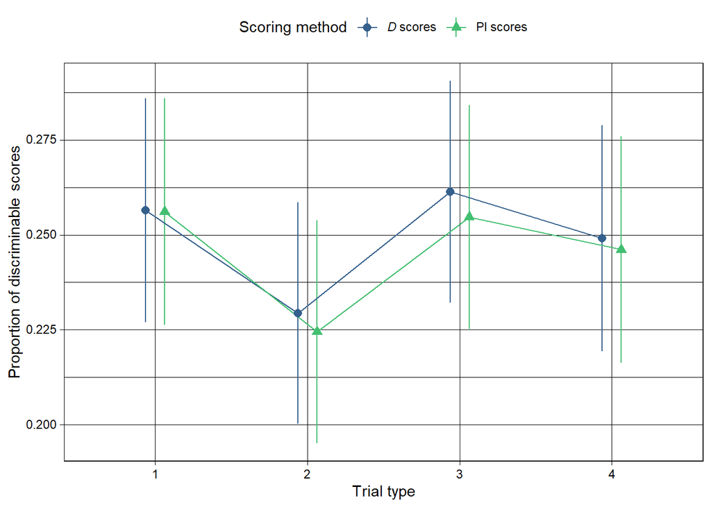

```r
# extract marginal means
results_emm_disciminability_scoring <-
  summary(emmeans(fit_disciminability_scoring, ~ DV_type | trial_type)) %>%
  select(DV_type, trial_type, estimate = emmean, ci_lower = lower.CL, ci_upper = upper.CL) %>%
  mutate(trial_type = fct_relevel(trial_type, "tt1", "tt2", "tt3", "tt4"))

# save to disk
write_rds(results_emm_disciminability_scoring, "models/results_emm_disciminability_scoring.rds")

ggplot(results_emm_disciminability_scoring, aes(trial_type, estimate, color = DV_type, shape = DV_type, group = DV_type)) +
  geom_linerange(aes(ymin = ci_lower, ymax = ci_upper), position = position_dodge(width = dodge_width)) +
  geom_line(position = position_dodge(width = dodge_width)) +
  geom_point(position = position_dodge(width = dodge_width), size = 2.5) +
  scale_shape_discrete() +
  scale_color_viridis_d(begin = 0.3, end = 0.7) +
  mdthemes::md_theme_linedraw() +
  scale_x_discrete(labels = c("tt1" = "1", "tt2" = "2", "tt3" = "3", "tt4" = "4")) +
  labs(x = "Trial type",
       y = "Proportion of discriminable scores",
       color = "Scoring method",
       shape = "Scoring method") +
  theme(legend.position = "top")
```

```r
# tests
emmeans(fit_disciminability_scoring, list(pairwise ~ DV_type | trial_type), adjust = "bonferroni")
```

```
## $`emmeans of DV_type | trial_type`
## trial_type = tt1:
##  DV_type    emmean     SE     df lower.CL upper.CL
##  *D* scores  0.256 0.0150 854253    0.227    0.286
##  PI scores   0.256 0.0152 883886    0.226    0.286
##
## trial_type = tt2:
##  DV_type    emmean     SE     df lower.CL upper.CL
##  *D* scores  0.229 0.0148 825463    0.200    0.259
##  PI scores   0.224 0.0150 841588    0.195    0.254
##
## trial_type = tt3:
##  DV_type    emmean     SE     df lower.CL upper.CL
##  *D* scores  0.261 0.0149 838713    0.232    0.291
##  PI scores   0.255 0.0150 859923    0.225    0.284
##
## trial_type = tt4:
##  DV_type    emmean     SE     df lower.CL upper.CL
##  *D* scores  0.249 0.0152 873761    0.219    0.279
##  PI scores   0.246 0.0152 869758    0.216    0.276
##
## Degrees-of-freedom method: kenward-roger
## Confidence level used: 0.95
##
## $`pairwise differences of DV_type | trial_type`
## trial_type = tt1:
##  2                        estimate     SE        df t.ratio p.value
##  (*D* scores) - PI scores 0.000358 0.0131 537298392 0.027   0.9783
##
## trial_type = tt2:
##  2                        estimate     SE        df t.ratio p.value
##  (*D* scores) - PI scores 0.004933 0.0126 639468762 0.392   0.6951
##
## trial_type = tt3:
##  2                        estimate     SE        df t.ratio p.value
##  (*D* scores) - PI scores 0.006687 0.0128 602671186 0.523   0.6007
##
## trial_type = tt4:
##  2                        estimate     SE        df t.ratio p.value
##  (*D* scores) - PI scores 0.002959 0.0132 521335623 0.223   0.8233
##
## Degrees-of-freedom method: kenward-roger
```

```r
emmeans(fit_disciminability_scoring, list(pairwise ~ DV_type), adjust = "bonferroni")
```

```
## $`emmeans of DV_type`
##  DV_type    emmean     SE     df lower.CL upper.CL
##  *D* scores  0.249 0.0128 445602    0.224    0.274
##  PI scores   0.245 0.0128 445243    0.220    0.270
##
## Results are averaged over the levels of: trial_type
## Degrees-of-freedom method: kenward-roger
## Confidence level used: 0.95
##
## $`pairwise differences of DV_type`
##  1                        estimate      SE        df t.ratio p.value
##  (*D* scores) - PI scores  0.00373 0.00647 572159896 0.578   0.5636
##
## Results are averaged over the levels of: trial_type
## Degrees-of-freedom method: kenward-roger
```

```r
emmeans(fit_disciminability_scoring, list(pairwise ~ trial_type | DV_type), adjust = "bonferroni")
```

```
## $`emmeans of trial_type | DV_type`
## DV_type = *D* scores:
##  trial_type emmean     SE     df lower.CL upper.CL
##  tt1         0.256 0.0150 854253    0.227    0.286
##  tt2         0.229 0.0148 825463    0.200    0.259
##  tt3         0.261 0.0149 838713    0.232    0.291
##  tt4         0.249 0.0152 873761    0.219    0.279
##
## DV_type = PI scores:
##  trial_type emmean     SE     df lower.CL upper.CL
##  tt1         0.256 0.0152 883886    0.226    0.286
##  tt2         0.224 0.0150 841588    0.195    0.254
##  tt3         0.255 0.0150 859923    0.225    0.284
##  tt4         0.246 0.0152 869758    0.216    0.276
##
## Degrees-of-freedom method: kenward-roger
## Confidence level used: 0.95
##
## $`pairwise differences of trial_type | DV_type`
## DV_type = *D* scores:
##  2         estimate     SE        df t.ratio p.value
##  tt1 - tt2  0.02703 0.0127 617394393  2.129  0.1993
##  tt1 - tt3 -0.00491 0.0128 599459142 -0.384  1.0000
##  tt1 - tt4  0.00734 0.0131 542490123  0.560  1.0000
##  tt2 - tt3 -0.03195 0.0126 643219580 -2.541  0.0662
##  tt2 - tt4 -0.01969 0.0129 577226722 -1.527  0.7605
##  tt3 - tt4  0.01225 0.0130 566701640  0.945  1.0000
##
## DV_type = PI scores:
##  2         estimate     SE        df t.ratio p.value
##  tt1 - tt2  0.03161 0.0131 548068838  2.418  0.0937
##  tt1 - tt3  0.00141 0.0132 529840137  0.107  1.0000
##  tt1 - tt4  0.00994 0.0133 509559521  0.746  1.0000
##  tt2 - tt3 -0.03019 0.0129 581113632 -2.342  0.1151
##  tt2 - tt4 -0.02167 0.0130 562977895 -1.668  0.5718
##  tt3 - tt4  0.00852 0.0131 539887774  0.649  1.0000
##
## Degrees-of-freedom method: kenward-roger
## P value adjustment: bonferroni method for 6 tests
```

### Compare CI bootstrapping methods

```r
# fit meta analytic model
fit_disciminability_method <-
  lmer(proportion_discriminable ~ 1 + trial_type * method + (1 | domain),
       weights = 1/variance,
       data = data_discriminability_D)

# results table
tab_model(fit_disciminability_method,
          string.p = "p (corrected)",
          ci.hyphen = ", ",
          #emph.p = FALSE,
          p.adjust = "holm")
```

|  | proportion discriminable |  |  |
| --- | --- | --- | --- |
| Predictors | Estimates | CI | p (corrected) |
| (Intercept) | 0.26 | 0.23, 0.28 | **<0.001** |
| trial_type [tt2] | -0.03 | -0.05, -0.00 | 0.288 |
| trial_type [tt3] | 0.00 | -0.02, 0.03 | 1.000 |
| trial_type [tt4] | -0.01 | -0.03, 0.01 | 1.000 |
| method [basic] | -0.00 | -0.02, 0.02 | 1.000 |
| method [normal] | -0.00 | -0.02, 0.02 | 1.000 |
| method [percent] | -0.00 | -0.02, 0.02 | 1.000 |
| trial_type [tt2] * method [basic] | -0.00 | -0.03, 0.03 | 1.000 |
| trial_type [tt3] * method [basic] | -0.00 | -0.03, 0.03 | 1.000 |
| trial_type [tt4] * method [basic] | -0.00 | -0.03, 0.03 | 1.000 |
| trial_type [tt2] * method [normal] | -0.00 | -0.03, 0.03 | 1.000 |
| trial_type [tt3] * method [normal] | -0.00 | -0.03, 0.03 | 1.000 |
| trial_type [tt4] * method [normal] | -0.00 | -0.03, 0.03 | 1.000 |
| trial_type [tt2] * method [percent] | -0.00 | -0.03, 0.03 | 1.000 |
| trial_type [tt3] * method [percent] | -0.00 | -0.03, 0.03 | 1.000 |
| trial_type [tt4] * method [percent] | -0.00 | -0.03, 0.03 | 1.000 |
| Random Effects |  |  |  |
| σ<sup>2</sup> | 3.70 |  |  |
| τ<sub>00</sub> <sub>domain</sub> | 0.00 |  |  |
| ICC | 0.00 |  |  |
| N <sub>domain</sub> | 35 |  |  |
| Observations | 560 |  |  |
| Marginal R<sup>2</sup> / Conditional R<sup>2</sup> | 0.000 / 0.001 |  |  |

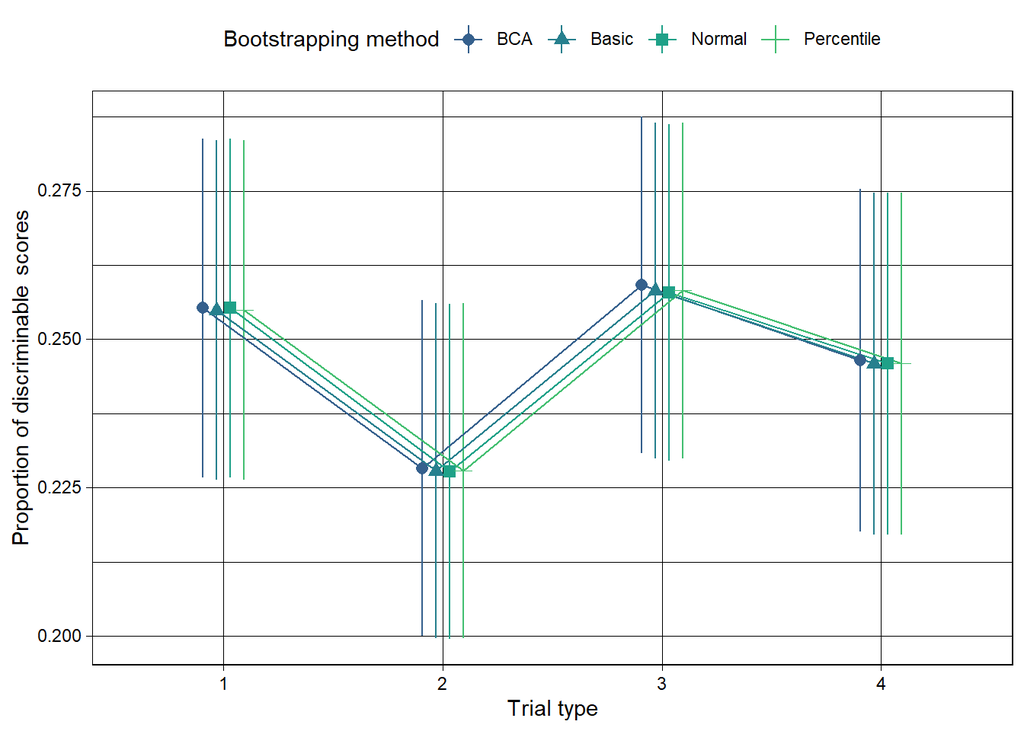

```r
# extract marginal means
results_emm_disciminability_method <-
  summary(emmeans(fit_disciminability_method, ~ method | trial_type)) %>%
  select(method, trial_type, estimate = emmean, ci_lower = lower.CL, ci_upper = upper.CL) %>%
  mutate(trial_type = fct_relevel(trial_type, "tt1", "tt2", "tt3", "tt4"))

# save to disk
write_rds(results_emm_disciminability_method, "models/results_emm_disciminability_method.rds")

# plot
ggplot(results_emm_disciminability_method, aes(trial_type, estimate, color = method, shape = method, group = method)) +
  geom_linerange(aes(ymin = ci_lower, ymax = ci_upper), position = position_dodge(width = dodge_width)) +
  geom_line(position = position_dodge(width = dodge_width)) +
  geom_point(position = position_dodge(width = dodge_width), size = 2.5) +
  scale_shape_discrete(labels = c("BCA", "Basic", "Normal", "Percentile")) +
  scale_color_viridis_d(begin = 0.3, end = 0.7, labels = c("BCA", "Basic", "Normal", "Percentile")) +
  mdthemes::md_theme_linedraw() +
  scale_x_discrete(labels = c("tt1" = "1", "tt2" = "2", "tt3" = "3", "tt4" = "4")) +
  labs(x = "Trial type",
       y = "Proportion of discriminable scores",
       color = "Bootstrapping method",
       shape = "Bootstrapping method") +
  theme(legend.position = "top")
```

```r
# tests
emmeans(fit_disciminability_method, list(pairwise ~ method | trial_type), adjust = "bonferroni")
```

```
## $`emmeans of method | trial_type`
## trial_type = tt1:
##  method  emmean     SE     df lower.CL upper.CL
##  bca      0.255 0.0146 149772    0.227    0.284
##  basic    0.255 0.0146 150150    0.226    0.283
##  normal   0.255 0.0146 149403    0.227    0.284
##  percent  0.255 0.0146 150150    0.226    0.283
##
## trial_type = tt2:
##  method  emmean     SE     df lower.CL upper.CL
##  bca      0.228 0.0144 144211    0.200    0.257
##  basic    0.228 0.0144 143454    0.200    0.256
##  normal   0.228 0.0144 143528    0.199    0.256
##  percent  0.228 0.0144 143454    0.200    0.256
##
## trial_type = tt3:
##  method  emmean     SE     df lower.CL upper.CL
##  bca      0.259 0.0145 146511    0.231    0.288
##  basic    0.258 0.0145 146051    0.230    0.287
##  normal   0.258 0.0145 146556    0.230    0.286
##  percent  0.258 0.0145 146051    0.230    0.287
##
## trial_type = tt4:
##  method  emmean     SE     df lower.CL upper.CL
##  bca      0.246 0.0147 154091    0.218    0.275
##  basic    0.246 0.0147 152975    0.217    0.275
##  normal   0.246 0.0147 152360    0.217    0.275
##  percent  0.246 0.0147 152975    0.217    0.275
##
## Degrees-of-freedom method: kenward-roger
## Confidence level used: 0.95
##
## $`pairwise differences of method | trial_type`
## trial_type = tt1:
##  2                   estimate     SE         df t.ratio p.value
##  bca - basic       0.00036987 0.0117 1242590668  0.032  1.0000
##  bca - normal      0.00000584 0.0117 1253793422  0.000  1.0000
##  bca - percent     0.00036987 0.0117 1242590668  0.032  1.0000
##  basic - normal   -0.00036403 0.0117 1248119518 -0.031  1.0000
##  basic - percent   0.00000000 0.0117 1237094500  0.000  1.0000
```

[output cut: 16 more lines]

```
##  basic - normal    0.00029765 0.0114 1372662958  0.026  1.0000
##  basic - percent   0.00000000 0.0114 1382469979  0.000  1.0000
##  normal - percent -0.00029765 0.0114 1372662958 -0.026  1.0000
##
## trial_type = tt4:
##  2                   estimate     SE         df t.ratio p.value
##  bca - basic       0.00051933 0.0120 1132439750  0.043  1.0000
##  bca - normal      0.00053503 0.0120 1140184619  0.045  1.0000
##  bca - percent     0.00051933 0.0120 1132439750  0.043  1.0000
##  basic - normal    0.00001569 0.0119 1157052786  0.001  1.0000
##  basic - percent   0.00000000 0.0120 1149118325  0.000  1.0000
##  normal - percent -0.00001569 0.0119 1157052786 -0.001  1.0000
##
## Degrees-of-freedom method: kenward-roger
## P value adjustment: bonferroni method for 6 tests
```

# CI widths as a proportion of observed range

## Calculate scores

```r
## calculate observed ranges
observed_range_estimates_D <- data_estimates_D %>%
  group_by(domain, method, trial_type) %>%
  dplyr::summarize(min = min(estimate, na.rm = TRUE),
                   max = max(estimate, na.rm = TRUE),
                   .groups = "drop") %>%
  mutate(range = max - min)

observed_range_estimates_PI <- data_estimates_PI %>%
  group_by(domain, method, trial_type) %>%
  dplyr::summarize(min = min(estimate, na.rm = TRUE),
                   max = max(estimate, na.rm = TRUE),
                   .groups = "drop") %>%
  mutate(range = max - min)


# calculate CI / range
data_ci_width_proportions_D <- data_estimates_D %>%
  # join this data into the original data
  full_join(observed_range_estimates_D, by = c("domain", "method", "trial_type")) %>%
  # calculate ci width as a proportion of observed range
  mutate(ci_width_proportion = ci_width / range) %>%
  mutate(DV_type = "*D* scores")

data_ci_width_proportions_PI <- data_estimates_PI %>%
  # join this data into the original data
  full_join(observed_range_estimates_PI, by = c("domain", "method", "trial_type")) %>%
  # calculate ci width as a proportion of observed range
  mutate(ci_width_proportion = ci_width / range) %>%
  mutate(DV_type = "PI scores")

# combine
data_ci_width_proportions_combined <-
  bind_rows(data_ci_width_proportions_D,
            data_ci_width_proportions_PI) %>%
  mutate(domain = as.factor(domain),
         method = fct_relevel(method, "bca", "basic", "normal", "percent"),
         trial_type = fct_relevel(trial_type, "tt1", "tt2", "tt3", "tt4"))
```

## Model

### Compare scoring method

```r
# fit model
fit_ci_width_proportions_scoring <-
  data_ci_width_proportions_combined %>%
  filter(method == "bca" & DV_type %in% c("*D* scores", "PI scores")) %>%
  lmer(ci_width_proportion ~ trial_type * DV_type + (1 | domain) + (1 | unique_id),
       data = .)

# results table
tab_model(fit_ci_width_proportions_scoring,
          string.p = "p (corrected)",
          ci.hyphen = ", ",
          #emph.p = FALSE,
          p.adjust = "holm")
```

|  | ci width proportion |  |  |
| --- | --- | --- | --- |
| Predictors | Estimates | CI | p (corrected) |
| (Intercept) | 0.82 | 0.76, 0.88 | **<0.001** |
| trial_type [tt2] | 0.06 | 0.05, 0.07 | **<0.001** |
| trial_type [tt3] | 0.01 | -0.00, 0.02 | 1.000 |
| trial_type [tt4] | 0.01 | -0.00, 0.02 | 1.000 |
| DV_type PI scores | -0.02 | -0.03, -0.01 | **<0.001** |
| trial_type [tt2] * DV_type PI scores | -0.00 | -0.02, 0.01 | 1.000 |
| trial_type [tt3] * DV_type PI scores | -0.02 | -0.03, -0.00 | 0.116 |
| trial_type [tt4] * DV_type PI scores | -0.00 | -0.01, 0.01 | 1.000 |
| Random Effects |  |  |  |
| σ<sup>2</sup> | 0.02 |  |  |
| τ<sub>00</sub> <sub>unique_id</sub> | 0.00 |  |  |
| τ<sub>00</sub> <sub>domain</sub> | 0.03 |  |  |
| ICC | 0.62 |  |  |
| N <sub>domain</sub> | 35 |  |  |
| N <sub>unique_id</sub> | 1464 |  |  |
| Observations | 11712 |  |  |
| Marginal R<sup>2</sup> / Conditional R<sup>2</sup> | 0.015 / 0.625 |  |  |

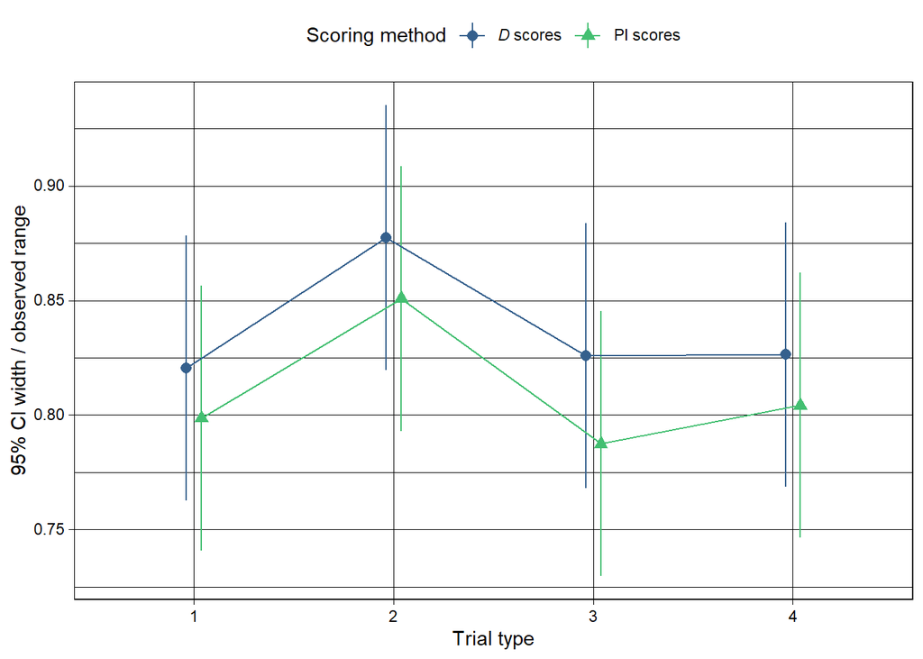

```r
# extract marginal means
results_emm_ci_width_proportions_scoring <-
  summary(emmeans(fit_ci_width_proportions_scoring, ~ DV_type | trial_type)) %>%
  select(DV_type, trial_type, estimate = emmean, ci_lower = asymp.LCL, ci_upper = asymp.UCL) %>%
  mutate(DV_type = fct_relevel(DV_type, "*D* scores", "*r*<sub>pb</sub> scores", "PI scores"),
         trial_type = fct_relevel(trial_type, "tt1", "tt2", "tt3", "tt4"))

# save to disk
write_rds(results_emm_ci_width_proportions_scoring, "models/results_emm_ci_width_proportions_scoring.rds")

# plot
dodge_width <- 0.15

ggplot(results_emm_ci_width_proportions_scoring, aes(trial_type, estimate, color = DV_type, shape = DV_type, group = DV_type)) +
  geom_linerange(aes(ymin = ci_lower, ymax = ci_upper), position = position_dodge(width = dodge_width)) +
  geom_line(position = position_dodge(width = dodge_width)) +
  geom_point(position = position_dodge(width = dodge_width), size = 2.5) +
  scale_shape_discrete(labels = c("*D* scores", "PI scores")) +
  scale_color_viridis_d(begin = 0.3, end = 0.7, labels = c("*D* scores", "PI scores")) +
  mdthemes::md_theme_linedraw() +
  scale_x_discrete(labels = c("tt1" = "1", "tt2" = "2", "tt3" = "3", "tt4" = "4")) +
  labs(x = "Trial type",
       y = "95% CI width / observed range",
       color = "Scoring method",
       shape = "Scoring method") +
  theme(legend.position = "top")
```

```r
# tests
emmeans(fit_ci_width_proportions_scoring, list(pairwise ~ DV_type | trial_type), adjust = "bonferroni")
```

```
## $`emmeans of DV_type | trial_type`
## trial_type = tt1:
##  DV_type    emmean     SE  df asymp.LCL asymp.UCL
##  *D* scores  0.821 0.0295 Inf     0.763     0.878
##  PI scores   0.799 0.0295 Inf     0.741     0.856
##
## trial_type = tt2:
##  DV_type    emmean     SE  df asymp.LCL asymp.UCL
##  *D* scores  0.878 0.0295 Inf     0.820     0.935
##  PI scores   0.851 0.0295 Inf     0.793     0.909
##
## trial_type = tt3:
##  DV_type    emmean     SE  df asymp.LCL asymp.UCL
##  *D* scores  0.826 0.0295 Inf     0.768     0.884
##  PI scores   0.787 0.0295 Inf     0.730     0.845
##
## trial_type = tt4:
##  DV_type    emmean     SE  df asymp.LCL asymp.UCL
##  *D* scores  0.826 0.0295 Inf     0.769     0.884
##  PI scores   0.804 0.0295 Inf     0.746     0.862
##
## Degrees-of-freedom method: asymptotic
## Confidence level used: 0.95
##
## $`pairwise differences of DV_type | trial_type`
## trial_type = tt1:
##  2                        estimate      SE  df z.ratio p.value
##  (*D* scores) - PI scores   0.0220 0.00511 Inf 4.303   <.0001
##
## trial_type = tt2:
##  2                        estimate      SE  df z.ratio p.value
##  (*D* scores) - PI scores   0.0267 0.00511 Inf 5.218   <.0001
##
## trial_type = tt3:
##  2                        estimate      SE  df z.ratio p.value
##  (*D* scores) - PI scores   0.0384 0.00511 Inf 7.514   <.0001
##
## trial_type = tt4:
##  2                        estimate      SE  df z.ratio p.value
##  (*D* scores) - PI scores   0.0221 0.00511 Inf 4.333   <.0001
##
## Degrees-of-freedom method: asymptotic
```

```r
emmeans(fit_ci_width_proportions_scoring, list(pairwise ~ trial_type | DV_type), adjust = "bonferroni")
```

```
## $`emmeans of trial_type | DV_type`
## DV_type = *D* scores:
##  trial_type emmean     SE  df asymp.LCL asymp.UCL
##  tt1         0.821 0.0295 Inf     0.763     0.878
##  tt2         0.878 0.0295 Inf     0.820     0.935
##  tt3         0.826 0.0295 Inf     0.768     0.884
##  tt4         0.826 0.0295 Inf     0.769     0.884
##
## DV_type = PI scores:
##  trial_type emmean     SE  df asymp.LCL asymp.UCL
##  tt1         0.799 0.0295 Inf     0.741     0.856
##  tt2         0.851 0.0295 Inf     0.793     0.909
##  tt3         0.787 0.0295 Inf     0.730     0.845
##  tt4         0.804 0.0295 Inf     0.746     0.862
##
## Degrees-of-freedom method: asymptotic
## Confidence level used: 0.95
##
## $`pairwise differences of trial_type | DV_type`
## DV_type = *D* scores:
##  2          estimate      SE  df z.ratio p.value
##  tt1 - tt2 -0.056993 0.00511 Inf -11.151 <.0001
##  tt1 - tt3 -0.005301 0.00511 Inf  -1.037 1.0000
##  tt1 - tt4 -0.005833 0.00511 Inf  -1.141 1.0000
##  tt2 - tt3  0.051691 0.00511 Inf  10.114 <.0001
##  tt2 - tt4  0.051160 0.00511 Inf  10.010 <.0001
##  tt3 - tt4 -0.000532 0.00511 Inf  -0.104 1.0000
##
## DV_type = PI scores:
##  2          estimate      SE  df z.ratio p.value
##  tt1 - tt2 -0.052317 0.00511 Inf -10.236 <.0001
##  tt1 - tt3  0.011111 0.00511 Inf   2.174 0.1783
##  tt1 - tt4 -0.005679 0.00511 Inf  -1.111 1.0000
##  tt2 - tt3  0.063427 0.00511 Inf  12.410 <.0001
##  tt2 - tt4  0.046638 0.00511 Inf   9.125 <.0001
##  tt3 - tt4 -0.016789 0.00511 Inf  -3.285 0.0061
##
## Degrees-of-freedom method: asymptotic
## P value adjustment: bonferroni method for 6 tests
```

### Compare CI bootstrapping methods

```r
data_ci_width_proportions_combined_method <-
  data_ci_width_proportions_D %>%
  mutate(domain = as.factor(domain),
         method = as.factor(method),
         method = fct_relevel(method, "bca", "basic", "normal", "percent"),
         trial_type = fct_relevel(trial_type, "tt1", "tt2", "tt3", "tt4")) %>%
  select(unique_id, domain, trial_type, method, ci_width_proportion)

# fit model
if(file.exists("models/fit_ci_width_proportions_method.rds")) {

  fit_ci_width_proportions_method <- read_rds("models/fit_ci_width_proportions_method.rds")

} else {

  fit_ci_width_proportions_method <-
    lmer(ci_width_proportion ~ trial_type * method + (1 | domain/unique_id),
         data = data_ci_width_proportions_combined_method)

  write_rds(fit_ci_width_proportions_method, "models/fit_ci_width_proportions_method.rds")

}

# fit model
fit_ci_width_proportions_method <-
  lmer(ci_width_proportion ~ trial_type * method + (1 | domain/unique_id),
       data = data_ci_width_proportions_combined_method)

# results table
tab_model(fit_ci_width_proportions_method,
          string.p = "p (corrected)",
          ci.hyphen = ", ",
          #emph.p = FALSE,
          p.adjust = "holm")
```

|  | ci width proportion |  |  |
| --- | --- | --- | --- |
| Predictors | Estimates | CI | p (corrected) |
| (Intercept) | 0.82 | 0.76, 0.88 | **<0.001** |
| trial_type [tt2] | 0.06 | 0.05, 0.07 | **<0.001** |
| trial_type [tt3] | 0.01 | -0.01, 0.02 | 1.000 |
| trial_type [tt4] | 0.01 | -0.00, 0.02 | 1.000 |
| method [basic] | -0.01 | -0.02, -0.00 | 0.140 |
| method [normal] | -0.01 | -0.02, 0.00 | 0.856 |
| method [percent] | -0.01 | -0.02, -0.00 | 0.140 |
| trial_type [tt2] * method [basic] | 0.01 | -0.01, 0.02 | 1.000 |
| trial_type [tt3] * method [basic] | 0.01 | -0.01, 0.02 | 1.000 |
| trial_type [tt4] * method [basic] | 0.01 | -0.01, 0.02 | 1.000 |
| trial_type [tt2] * method [normal] | 0.01 | -0.01, 0.02 | 1.000 |
| trial_type [tt3] * method [normal] | 0.00 | -0.01, 0.02 | 1.000 |
| trial_type [tt4] * method [normal] | 0.01 | -0.01, 0.02 | 1.000 |
| trial_type [tt2] * method [percent] | 0.01 | -0.01, 0.02 | 1.000 |
| trial_type [tt3] * method [percent] | 0.01 | -0.01, 0.02 | 1.000 |
| trial_type [tt4] * method [percent] | 0.01 | -0.01, 0.02 | 1.000 |
| Random Effects |  |  |  |
| σ<sup>2</sup> | 0.02 |  |  |
| τ<sub>00</sub> <sub>unique_id:domain</sub> | 0.00 |  |  |
| τ<sub>00</sub> <sub>domain</sub> | 0.03 |  |  |
| ICC | 0.62 |  |  |
| N <sub>unique_id</sub> | 1464 |  |  |
| N <sub>domain</sub> | 35 |  |  |
| Observations | 23424 |  |  |
| Marginal R<sup>2</sup> / Conditional R<sup>2</sup> | 0.011 / 0.621 |  |  |

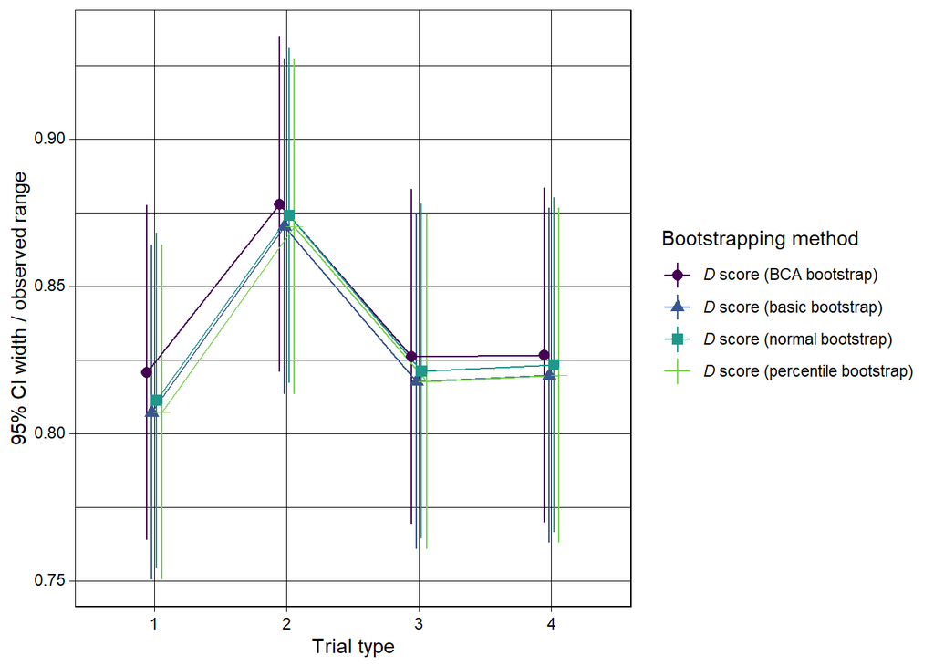

```r
# extract marginal means
results_emm_ci_width_proportions_method <-
  summary(emmeans(fit_ci_width_proportions_method, ~ trial_type | method)) %>%
  select(method, trial_type, estimate = emmean, ci_lower = asymp.LCL, ci_upper = asymp.UCL) %>%
  mutate(method = fct_relevel(method, "bca", "basic", "normal", "percent", "arithmethic"),
         trial_type = fct_relevel(trial_type, "tt1", "tt2", "tt3", "tt4"))

# save to disk
write_rds(results_emm_ci_width_proportions_method, "models/results_emm_ci_width_proportions_method.rds")

# plot
ggplot(results_emm_ci_width_proportions_method, aes(trial_type, estimate, color = method, shape = method, group = method)) +
  geom_linerange(aes(ymin = ci_lower, ymax = ci_upper), position = position_dodge(width = dodge_width)) +
  geom_line(position = position_dodge(width = dodge_width)) +
  geom_point(position = position_dodge(width = dodge_width), size = 2.5) +
  scale_shape_discrete(labels = c("*D* score (BCA bootstrap)",
                                  "*D* score (basic bootstrap)",
                                  "*D* score (normal bootstrap)",
                                  "*D* score (percentile bootstrap)",
                                  "*r*<sub>pb</sub> (arithmethic)")) +
  scale_color_viridis_d(end = 0.8, labels = c("*D* score (BCA bootstrap)",
                                              "*D* score (basic bootstrap)",
                                              "*D* score (normal bootstrap)",
                                              "*D* score (percentile bootstrap)",
                                              "*r*<sub>pb</sub> (arithmethic)")) +
  mdthemes::md_theme_linedraw() +
  scale_x_discrete(labels = c("tt1" = "1", "tt2" = "2", "tt3" = "3", "tt4" = "4")) +
  labs(x = "Trial type",
       y = "95% CI width / observed range",
       color = "Bootstrapping method",
       shape = "Bootstrapping method") +
  theme(legend.position = "right")
```

```r
# tests
emmeans(fit_ci_width_proportions_method, list(pairwise ~ method | trial_type), adjust = "bonferroni")
```

```
## $`emmeans of method | trial_type`
## trial_type = tt1:
##  method  emmean    SE  df asymp.LCL asymp.UCL
##  bca      0.821 0.029 Inf     0.764     0.878
##  basic    0.807 0.029 Inf     0.750     0.864
##  normal   0.811 0.029 Inf     0.754     0.868
##  percent  0.807 0.029 Inf     0.750     0.864
##
## trial_type = tt2:
##  method  emmean    SE  df asymp.LCL asymp.UCL
##  bca      0.878 0.029 Inf     0.821     0.935
##  basic    0.870 0.029 Inf     0.813     0.927
##  normal   0.874 0.029 Inf     0.817     0.931
##  percent  0.870 0.029 Inf     0.813     0.927
##
## trial_type = tt3:
##  method  emmean    SE  df asymp.LCL asymp.UCL
##  bca      0.826 0.029 Inf     0.769     0.883
##  basic    0.818 0.029 Inf     0.761     0.874
##  normal   0.821 0.029 Inf     0.764     0.878
##  percent  0.818 0.029 Inf     0.761     0.874
##
## trial_type = tt4:
##  method  emmean    SE  df asymp.LCL asymp.UCL
##  bca      0.827 0.029 Inf     0.770     0.883
##  basic    0.820 0.029 Inf     0.763     0.877
##  normal   0.823 0.029 Inf     0.766     0.880
##  percent  0.820 0.029 Inf     0.763     0.877
##
## Degrees-of-freedom method: asymptotic
## Confidence level used: 0.95
##
## $`pairwise differences of method | trial_type`
## trial_type = tt1:
##  2                estimate      SE  df z.ratio p.value
##  bca - basic       0.01354 0.00526 Inf  2.575  0.0602
##  bca - normal      0.00949 0.00526 Inf  1.803  0.4279
##  bca - percent     0.01354 0.00526 Inf  2.575  0.0602
##  basic - normal   -0.00406 0.00526 Inf -0.771  1.0000
##  basic - percent   0.00000 0.00526 Inf  0.000  1.0000
```

[output cut: 16 more lines]

```
##  basic - normal   -0.00365 0.00526 Inf -0.694  1.0000
##  basic - percent   0.00000 0.00526 Inf  0.000  1.0000
##  normal - percent  0.00365 0.00526 Inf  0.694  1.0000
##
## trial_type = tt4:
##  2                estimate      SE  df z.ratio p.value
##  bca - basic       0.00687 0.00526 Inf  1.306  1.0000
##  bca - normal      0.00324 0.00526 Inf  0.615  1.0000
##  bca - percent     0.00687 0.00526 Inf  1.306  1.0000
##  basic - normal   -0.00363 0.00526 Inf -0.691  1.0000
##  basic - percent   0.00000 0.00526 Inf  0.000  1.0000
##  normal - percent  0.00363 0.00526 Inf  0.691  1.0000
##
## Degrees-of-freedom method: asymptotic
## P value adjustment: bonferroni method for 6 tests
```